# Current smoker

# 1 Description of DataSchema variable

The description of harmonised variable is the following:

- Short name: `current_smoking`
- Variable label: `Current smoker`
- Variable description: `Current smoker. Any type of tobacco smoking.`
- Domain: `Lifestyle and health behaviours`
- Value type: `categorical`
- Category coding:

| **Code** | **Category Label** |
| --- | --- |
| 0 | No |
| 1 | Yes |

- Category missings:

| **Code** | **Category Label** |
| --- | --- |
| 991 | CAPI/interviewer error |
| 992 | Impute |
| 993 | Disable to measure |
| 994 | Not attempt/not done |
| 995 | Does not answer |
| 996 | Not applicable |
| 997 | Refuse |
| 998 | Do not know |
| 999 | Missing |

# 2 Data process

## 2.1 Cuba

### 2.1.1 Wave 1

#### 2.1.1.1 Study-specific variable description

| **Name** | `PSMKNOW` |
| --- | --- |
| **Label** | `still smoking regularly?` |
| **Table name** | `1066-Cuba-Baseline` |
| **Categories** | `0 = No` `1 = Yes` |
| **Missings** | `NA` |
| **Description** |  |

PSMKNOW

| Sample size | Missing values |
| --- | --- |
| 2813 | 1541 |

Category

|  | 0 | 1 |
| --- | --- | --- |
| Frequency | 730.00 | 542.00 |
| Percentage | 25.95 | 19.27 |

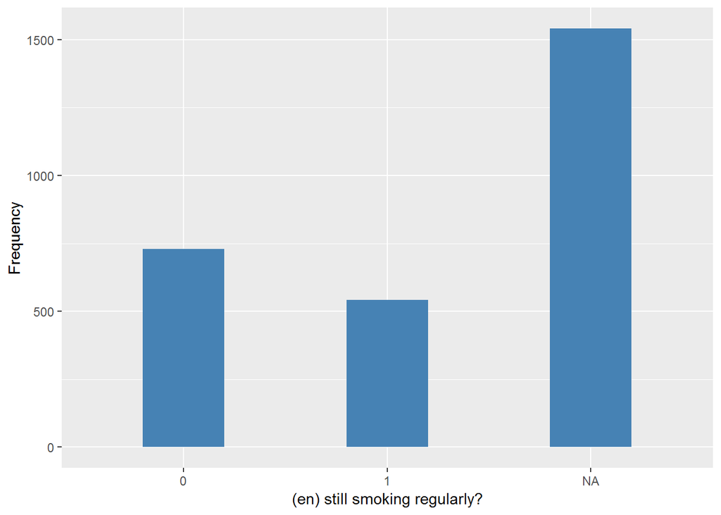

#### 2.1.1.2 Harmonisation algorithm

To compute the harmonize variable from the study-specific variable it has to be recoded as follows:

- `0 into 0`
- `1 into 1`
- `NA into 999`

```r
t1066_ds_cuba_w1 <- tibble(id = t1066_cuba_w1$id)
t1066_ds_cuba_w1$current_smoking <- Recode(t1066_cuba_w1$PSMKNOW, "1 = '1';0='0'; NA='999'")
t1066_ds_cuba_w1$current_smoking <- labelled(t1066_ds_cuba_w1$current_smoking,
    labels = c(No = 0, Yes = 1, Missing = 999, Do_not_know = 998, Refuse = 997,
        Not_applicable = 996, Does_not_answer = 995, Not_attempt_not_done = 994,
        Disable_to_measure = 993, Impute = 992, CAPI_interviewer_error = 991))
```

#### 2.1.1.3 Statistical description of the new harmonised variable

Current smoker

| Sample size | Missing values |
| --- | --- |
| 2813 | 1541 |

Category

|  | 0 | 1 |
| --- | --- | --- |
| Frequency | 730.00 | 542.00 |
| Percentage | 25.95 | 19.27 |

Type of missing

|  | 991 | 992 | 993 | 994 | 995 | 996 | 997 | 998 | 999 | NA |
| --- | --- | --- | --- | --- | --- | --- | --- | --- | --- | --- |
| Frequency | 0 | 0 | 0 | 0 | 0 | 0 | 0 | 0 | 1541.00 | 0 |
| Percentage | 0 | 0 | 0 | 0 | 0 | 0 | 0 | 0 | 54.78 | 0 |

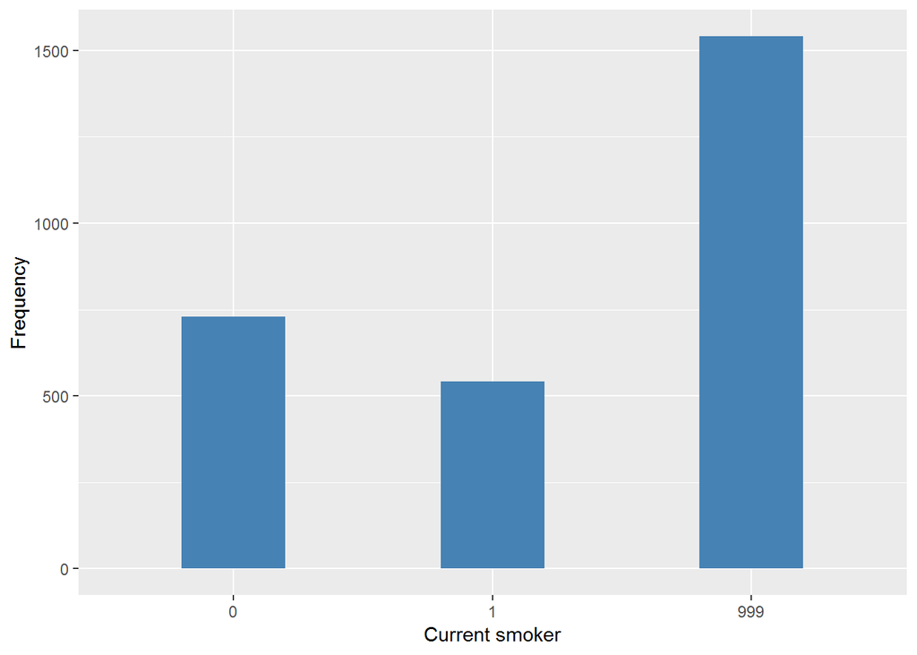

#### 2.1.1.4 Validation

|  | 0->0 | 1->1 | NA->999 |
| --- | --- | --- | --- |
| BeforeH | 730 | 542 | 1541 |
| AfterH | 730 | 542 | 1541 |

### 2.1.2 Wave 2

#### 2.1.2.1 Study-specific variable description

| **Name** | `f_PSMOKE1` |
| --- | --- |
| **Label** | `in the last week, did you smoke or use tobacco?` |
| **Table name** | `1066-Cuba-Followup` |
| **Categories** | `0 = No` `1 = Yes` |
| **Missings** | `NA` |
| **Description** |  |

f_PSMOKE1

| Sample size | Missing values |
| --- | --- |
| 2007 | 23 |

Category

|  | 0 | 1 |
| --- | --- | --- |
| Frequency | 1746 | 238.00 |
| Percentage | 87 | 11.86 |

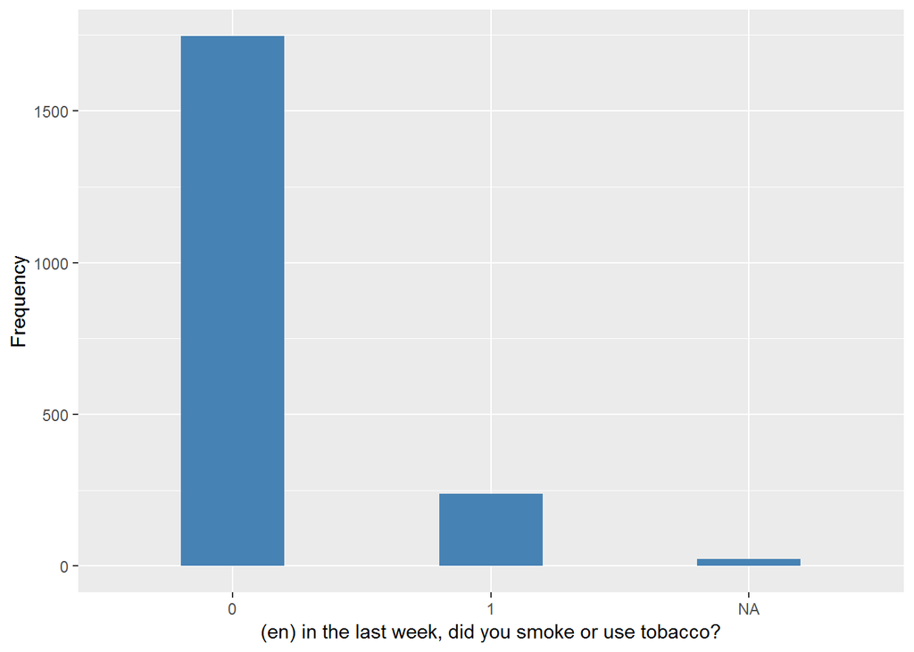

#### 2.1.2.2 Harmonisation algorithm

To compute the harmonize variable from the study-specific variable it has to be recoded as follows:

- `0 into 0`
- `1 into 1`
- `NA into 999`

```r
t1066_ds_cuba_w2 <- tibble(id = t1066_cuba_w2$id)
t1066_ds_cuba_w2$current_smoking <- Recode(t1066_cuba_w2$f_PSMOKE1, "0 = '0';1 ='1'; NA='999'")
t1066_ds_cuba_w2$current_smoking <- labelled(t1066_ds_cuba_w2$current_smoking,
    labels = c(No = 0, Yes = 1, Missing = 999, Do_not_know = 998, Refuse = 997,
        Not_applicable = 996, Does_not_answer = 995, Not_attempt_not_done = 994,
        Disable_to_measure = 993, Impute = 992, CAPI_interviewer_error = 991))
```

#### 2.1.2.3 Statistical description of the new harmonised variable

Current smoker

| Sample size | Missing values |
| --- | --- |
| 2007 | 23 |

Category

|  | 0 | 1 |
| --- | --- | --- |
| Frequency | 1746 | 238.00 |
| Percentage | 87 | 11.86 |

Type of missing

|  | 991 | 992 | 993 | 994 | 995 | 996 | 997 | 998 | 999 | NA |
| --- | --- | --- | --- | --- | --- | --- | --- | --- | --- | --- |
| Frequency | 0 | 0 | 0 | 0 | 0 | 0 | 0 | 0 | 23.00 | 0 |
| Percentage | 0 | 0 | 0 | 0 | 0 | 0 | 0 | 0 | 1.15 | 0 |

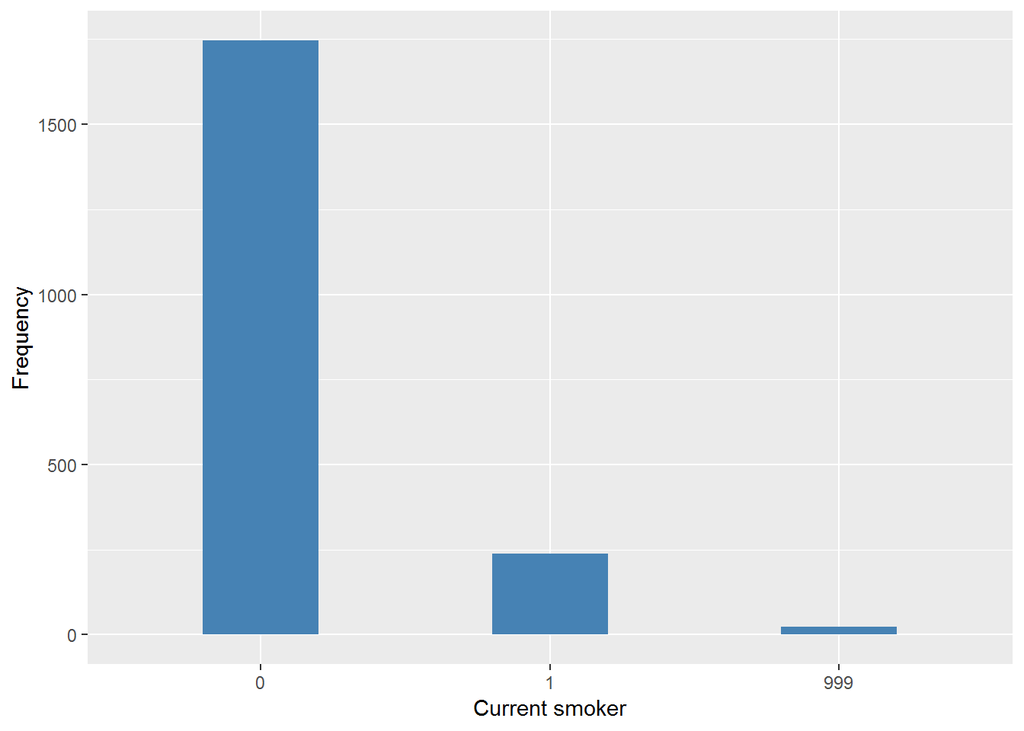

#### 2.1.2.4 Validation

|  | 0->0 | 1->1 | NA->999 |
| --- | --- | --- | --- |
| BeforeH | 1746 | 238 | 23 |
| AfterH | 1746 | 238 | 23 |

## 2.2 India

### 2.2.1 Wave 1

#### 2.2.1.1 Study-specific variable description

| **Name** | `PSMKNOW` |
| --- | --- |
| **Label** | `still smoking regularly?` |
| **Table name** | `1066-India-Baseline` |
| **Categories** | `0 = No` `1 = Yes` |
| **Missings** | `NA` |
| **Description** |  |

PSMKNOW

| Sample size | Missing values |
| --- | --- |
| 2004 | 1207 |

Category

|  | 0 | 1 |
| --- | --- | --- |
| Frequency | 128.00 | 669.00 |
| Percentage | 6.39 | 33.38 |

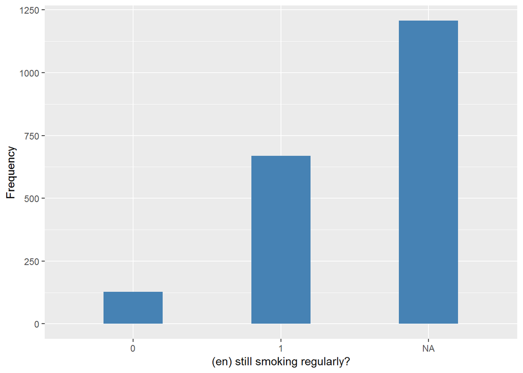

#### 2.2.1.2 Harmonisation algorithm

To compute the harmonize variable from the study-specific variable it has to be recoded as follows:

- `0 into 0`
- `1 into 1`
- `NA into 999`

```r
t1066_ds_india_w1 <- tibble(id = t1066_india_w1$id)
t1066_ds_india_w1$current_smoking <- Recode(t1066_india_w1$PSMKNOW, "1 = '1';0='0';NA=999")
t1066_ds_india_w1$current_smoking <- labelled(t1066_ds_india_w1$current_smoking,
    labels = c(No = 0, Yes = 1, Missing = 999, Do_not_know = 998, Refuse = 997,
        Not_applicable = 996, Does_not_answer = 995, Not_attempt_not_done = 994,
        Disable_to_measure = 993, Impute = 992, CAPI_interviewer_error = 991))
```

#### 2.2.1.3 Statistical description of the new harmonised variable

Current smoker

| Sample size | Missing values |
| --- | --- |
| 2004 | 1207 |

Category

|  | 0 | 1 |
| --- | --- | --- |
| Frequency | 128.00 | 669.00 |
| Percentage | 6.39 | 33.38 |

Type of missing

|  | 991 | 992 | 993 | 994 | 995 | 996 | 997 | 998 | 999 | NA |
| --- | --- | --- | --- | --- | --- | --- | --- | --- | --- | --- |
| Frequency | 0 | 0 | 0 | 0 | 0 | 0 | 0 | 0 | 1207.00 | 0 |
| Percentage | 0 | 0 | 0 | 0 | 0 | 0 | 0 | 0 | 60.23 | 0 |

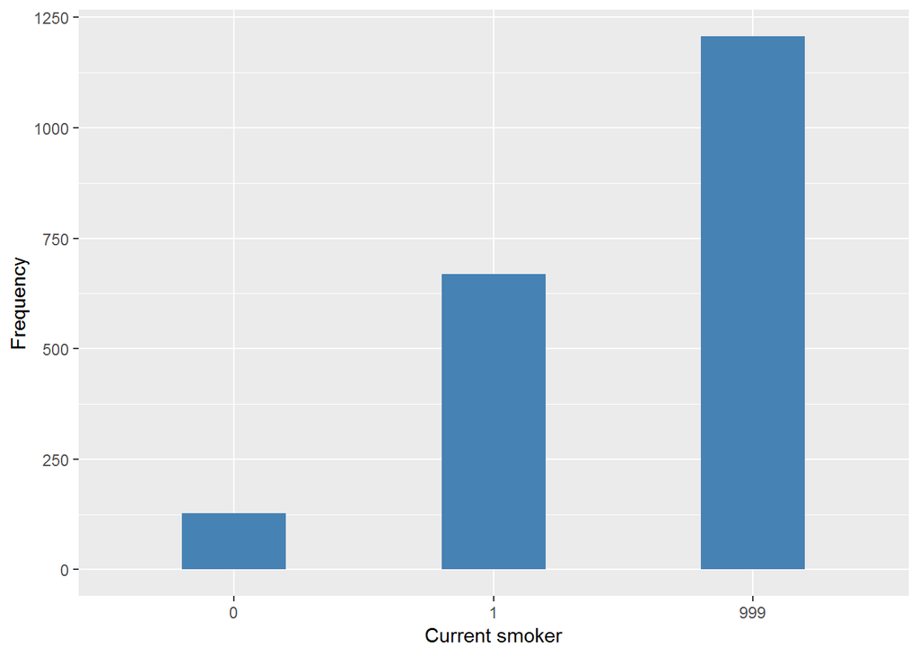

#### 2.2.1.4 Validation

|  | 0->0 | 1->1 | NA->999 |
| --- | --- | --- | --- |
| BeforeH | 128 | 669 | 1207 |
| AfterH | 128 | 669 | 1207 |

## 2.3 UrbanChina

### 2.3.1 Wave 1

#### 2.3.1.1 Study-specific variable description

| **Name** | `PSMKNOW` |
| --- | --- |
| **Label** | `still smoking regularly?` |
| **Table name** | `1066-UrbanChina-Baseline` |
| **Categories** | `0 = No` `1 = Yes` |
| **Missings** | `NA` |
| **Description** |  |

PSMKNOW

| Sample size | Missing values |
| --- | --- |
| 1160 | 875 |

Category

|  | 0 | 1 |
| --- | --- | --- |
| Frequency | 92.00 | 193.00 |
| Percentage | 7.93 | 16.64 |

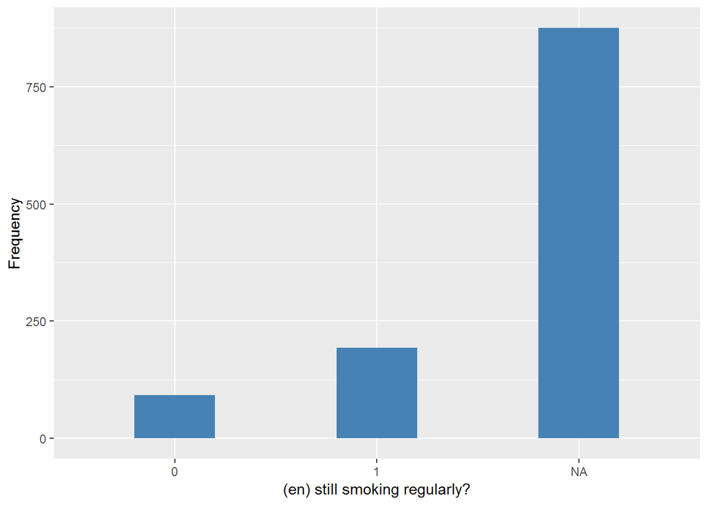

#### 2.3.1.2 Harmonisation algorithm

To compute the harmonize variable from the study-specific variable it has to be recoded as follows:

- `0 into 0`
- `1 into 1`
- `NA into 999`

```r
t1066_ds_UCh_w1 <- tibble(id = t1066_UCh_w1$id)
t1066_ds_UCh_w1$current_smoking <- Recode(t1066_UCh_w1$PSMKNOW, "0 = '0';1 ='1';NA = '999'")
t1066_ds_UCh_w1$current_smoking <- labelled(t1066_ds_UCh_w1$current_smoking,
    labels = c(No = 0, Yes = 1, Missing = 999, Do_not_know = 998, Refuse = 997,
        Not_applicable = 996, Does_not_answer = 995, Not_attempt_not_done = 994,
        Disable_to_measure = 993, Impute = 992, CAPI_interviewer_error = 991))
```

#### 2.3.1.3 Statistical description of the new harmonised variable

current_smoking

| Sample size | Missing values |
| --- | --- |
| 1160 | 875 |

Category

|  | 0 | 1 |
| --- | --- | --- |
| Frequency | 92.00 | 193.00 |
| Percentage | 7.93 | 16.64 |

Type of missing

|  | 991 | 992 | 993 | 994 | 995 | 996 | 997 | 998 | 999 | NA |
| --- | --- | --- | --- | --- | --- | --- | --- | --- | --- | --- |
| Frequency | 0 | 0 | 0 | 0 | 0 | 0 | 0 | 0 | 875.00 | 0 |
| Percentage | 0 | 0 | 0 | 0 | 0 | 0 | 0 | 0 | 75.43 | 0 |

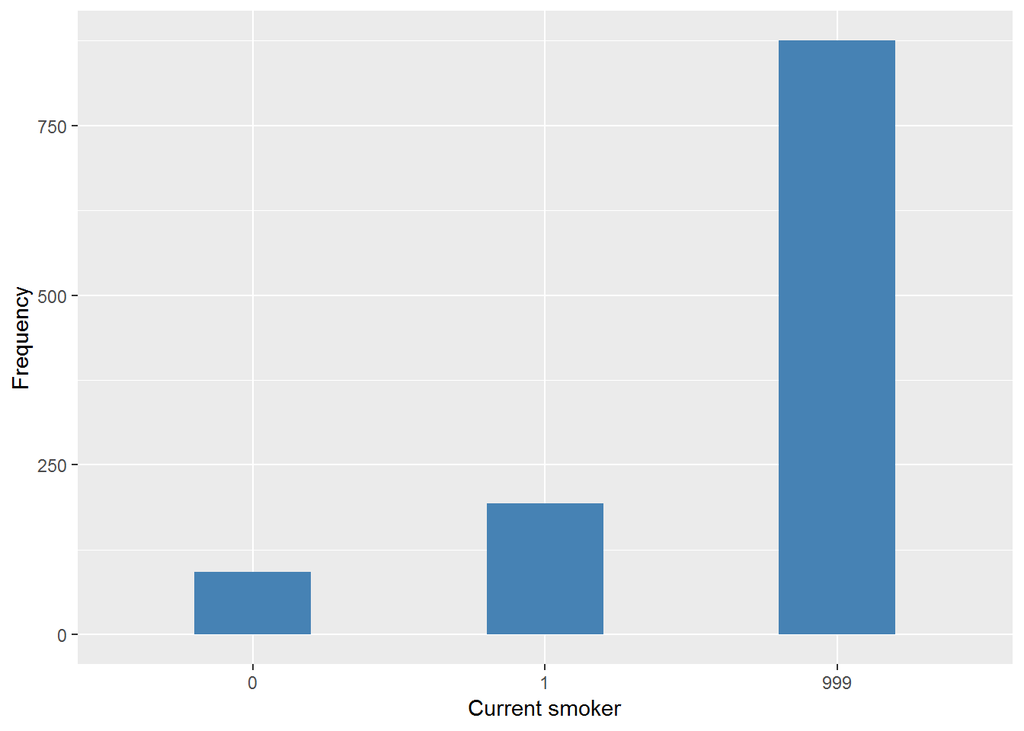

#### 2.3.1.4 Validation

|  | 0->0 | 1->1 | NA->999 |
| --- | --- | --- | --- |
| BeforeH | 92 | 193 | 875 |
| AfterH | 92 | 193 | 875 |

### 2.3.2 Wave 2

#### 2.3.2.1 Study-specific variable description

| **Name** | `f_PSMOKE1` |
| --- | --- |
| **Label** | `in the last week, did you smoke or use tobacco?` |
| **Table name** | `1066-UrbanChina-Followup` |
| **Categories** | `0 = No` `1 = Yes` |
| **Missings** |  |
| **Description** |  |

f_PSMOKE1

| Sample size | Missing values |
| --- | --- |
| 741 | 0 |

Category

|  | 0 | 1 |
| --- | --- | --- |
| Frequency | 620.00 | 121.00 |
| Percentage | 83.67 | 16.33 |

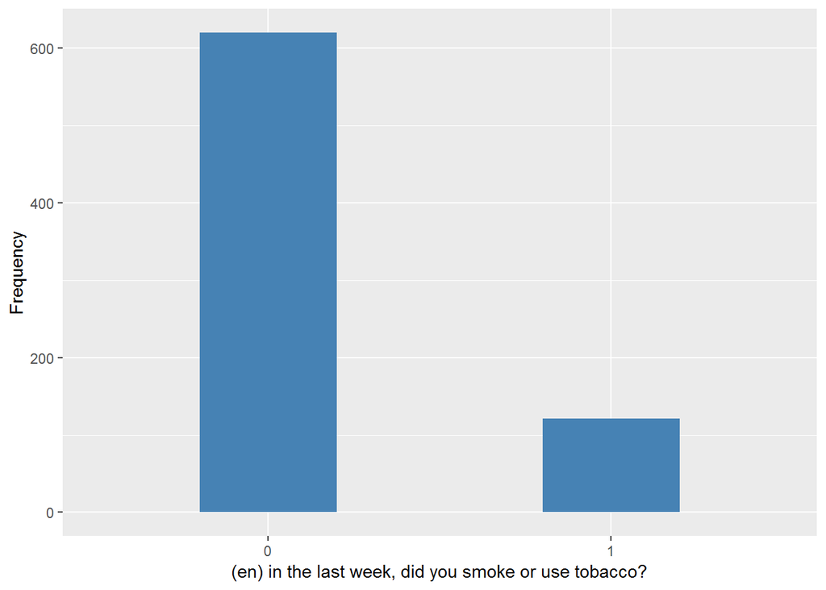

#### 2.3.2.2 Harmonisation algorithm

To compute the harmonize variable from the study-specific variable it has to be recoded as follows:

- `0 into 0`
- `1 into 1`

```r
t1066_ds_UCh_w2 <- tibble(id = t1066_UCh_w2$id)
t1066_ds_UCh_w2$current_smoking <- Recode(t1066_UCh_w2$f_PSMOKE1, "0 = '0';1 ='1'")
t1066_ds_UCh_w2$current_smoking <- labelled(t1066_ds_UCh_w2$current_smoking,
    labels = c(No = 0, Yes = 1, Missing = 999, Do_not_know = 998, Refuse = 997,
        Not_applicable = 996, Does_not_answer = 995, Not_attempt_not_done = 994,
        Disable_to_measure = 993, Impute = 992, CAPI_interviewer_error = 991))
```

#### 2.3.2.3 Statistical description of the new harmonised variable

Current smoker

| Sample size | Missing values |
| --- | --- |
| 741 | 0 |

Category

|  | 0 | 1 |
| --- | --- | --- |
| Frequency | 620.00 | 121.00 |
| Percentage | 83.67 | 16.33 |

Type of missing

|  | 991 | 992 | 993 | 994 | 995 | 996 | 997 | 998 | 999 | NA |
| --- | --- | --- | --- | --- | --- | --- | --- | --- | --- | --- |
| Frequency | 0 | 0 | 0 | 0 | 0 | 0 | 0 | 0 | 0 | 0 |
| Percentage | 0 | 0 | 0 | 0 | 0 | 0 | 0 | 0 | 0 | 0 |

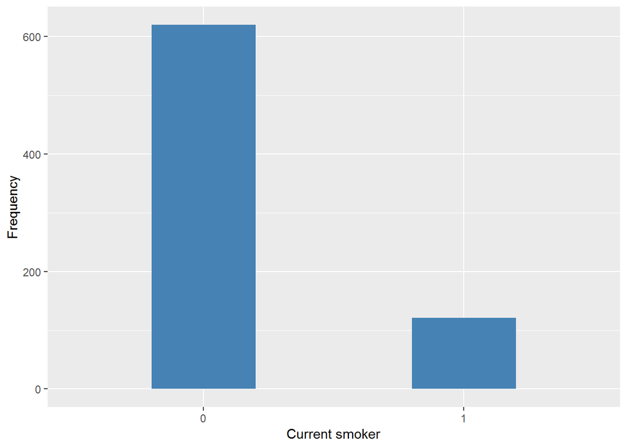

#### 2.3.2.4 Validation

|  | 0->0 | 1->1 |
| --- | --- | --- |
| BeforeH | 620 | 121 |
| AfterH | 620 | 121 |

## 2.4 RuralChina

### 2.4.1 Wave 1

#### 2.4.1.1 Study-specific variable description

| **Name** | `PSMKNOW` |
| --- | --- |
| **Label** | `still smoking regularly?` |
| **Table name** | `1066-RuralChina-Baseline` |
| **Categories** | `0 = No` `1 = Yes` |
| **Missings** | `NA` |
| **Description** |  |

PSMKNOW

| Sample size | Missing values |
| --- | --- |
| 1002 | 666 |

Category

|  | 0 | 1 |
| --- | --- | --- |
| Frequency | 31.00 | 305.00 |
| Percentage | 3.09 | 30.44 |

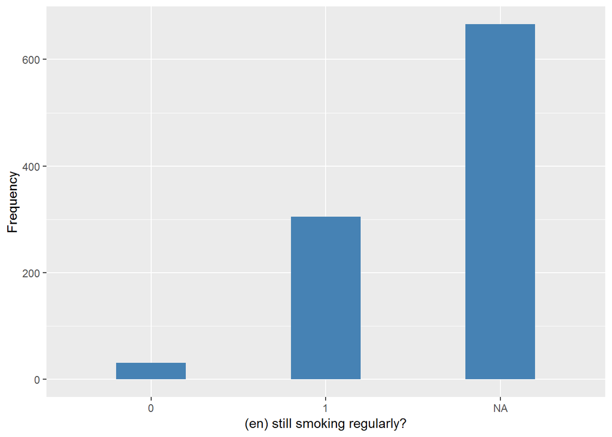

#### 2.4.1.2 Harmonisation algorithm

To compute the harmonize variable from the study-specific variable it has to be recoded as follows:

- `0 into 0`
- `1 into 1`
- `NA into 999`

```r
t1066_ds_RCh_w1 <- tibble(id = t1066_RCh_w1$id)
t1066_ds_RCh_w1$current_smoking <- Recode(t1066_RCh_w1$PSMKNOW, "0 = '0';1='1';NA='999'")
t1066_ds_RCh_w1$current_smoking <- labelled(t1066_ds_RCh_w1$current_smoking,
    labels = c(No = 0, Yes = 1, Missing = 999, Do_not_know = 998, Refuse = 997,
        Not_applicable = 996, Does_not_answer = 995, Not_attempt_not_done = 994,
        Disable_to_measure = 993, Impute = 992, CAPI_interviewer_error = 991))
```

#### 2.4.1.3 Statistical description of the new harmonised variable

Current smoker

| Sample size | Missing values |
| --- | --- |
| 1002 | 666 |

Category

|  | 0 | 1 |
| --- | --- | --- |
| Frequency | 31.00 | 305.00 |
| Percentage | 3.09 | 30.44 |

Type of missing

|  | 991 | 992 | 993 | 994 | 995 | 996 | 997 | 998 | 999 | NA |
| --- | --- | --- | --- | --- | --- | --- | --- | --- | --- | --- |
| Frequency | 0 | 0 | 0 | 0 | 0 | 0 | 0 | 0 | 666.00 | 0 |
| Percentage | 0 | 0 | 0 | 0 | 0 | 0 | 0 | 0 | 66.47 | 0 |

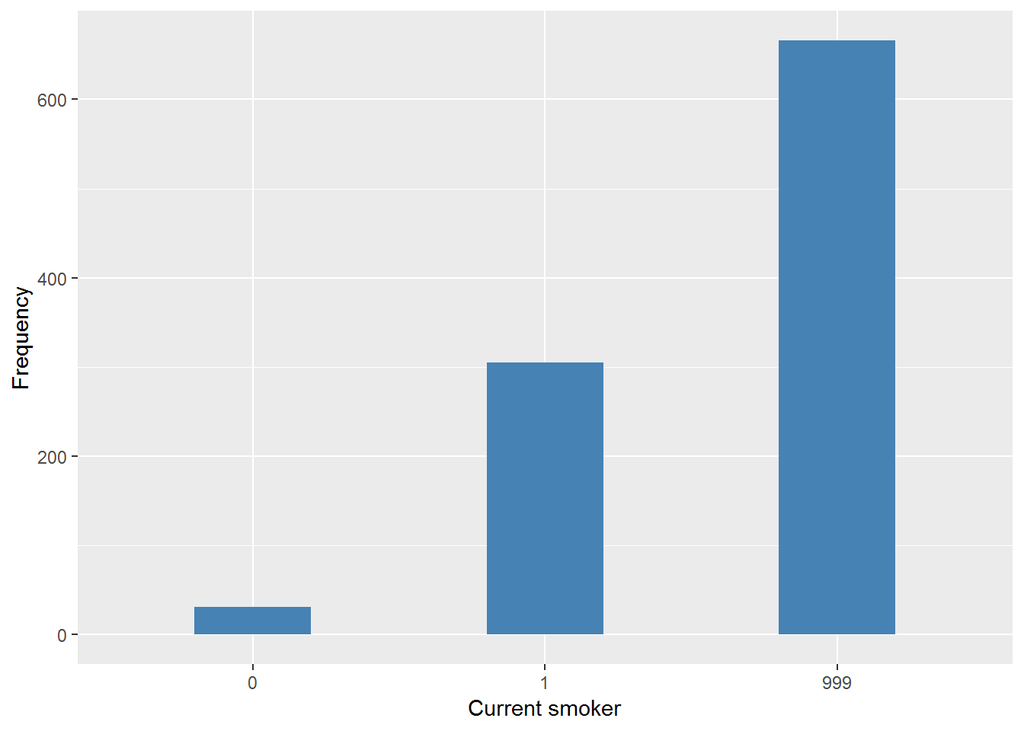

#### 2.4.1.4 Validation

|  | 0->0 | 1->1 | NA->999 |
| --- | --- | --- | --- |
| BeforeH | 31 | 305 | 666 |
| AfterH | 31 | 305 | 666 |

### 2.4.2 Wave 2

#### 2.4.2.1 Study-specific variable description

| **Name** | `f_PSMOKE1` |
| --- | --- |
| **Label** | `in the last week, did you smoke or use tobacco?` |
| **Table name** | `1066-RuralChina-Followup` |
| **Categories** | `0 = No` `1 = Yes` |
| **Missings** | `NA` |
| **Description** |  |

$values_table 0 1 Frequency 501.00 207.00 Percentage 70.46 29.11

$n_table Sample size Missing values [1,] 711 3

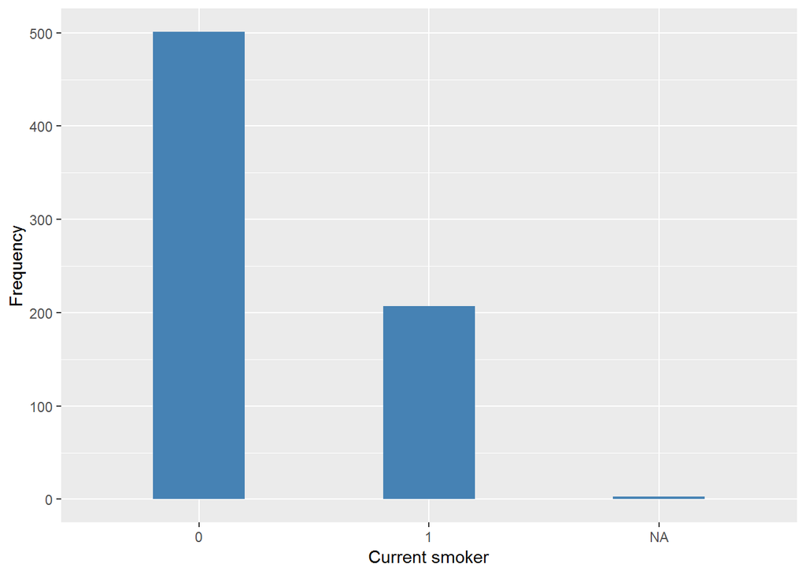

#### 2.4.2.2 Harmonisation algorithm

To compute the harmonize variable from the study-specific variable it has to be recoded as follows:

- `0 into 0`
- `1 into 1`
- `NA into 999`

```r
t1066_ds_RCh_w2 <- tibble(id = t1066_RCh_w2$id)
t1066_ds_RCh_w2$current_smoking <- Recode(t1066_RCh_w2$f_PSMOKE1, "0 = '0';1='1'; NA='999'")
t1066_ds_RCh_w2$current_smoking <- labelled(t1066_ds_RCh_w2$current_smoking,
    labels = c(No = 0, Yes = 1, Missing = 999, Do_not_know = 998, Refuse = 997,
        Not_applicable = 996, Does_not_answer = 995, Not_attempt_not_done = 994,
        Disable_to_measure = 993, Impute = 992, CAPI_interviewer_error = 991))
```

#### 2.4.2.3 Statistical description of the new harmonised variable

Current smoker

| Sample size | Missing values |
| --- | --- |
| 711 | 3 |

Category

|  | 0 | 1 |
| --- | --- | --- |
| Frequency | 501.00 | 207.00 |
| Percentage | 70.46 | 29.11 |

Type of missing

|  | 991 | 992 | 993 | 994 | 995 | 996 | 997 | 998 | 999 | NA |
| --- | --- | --- | --- | --- | --- | --- | --- | --- | --- | --- |
| Frequency | 0 | 0 | 0 | 0 | 0 | 0 | 0 | 0 | 3.00 | 0 |
| Percentage | 0 | 0 | 0 | 0 | 0 | 0 | 0 | 0 | 0.42 | 0 |

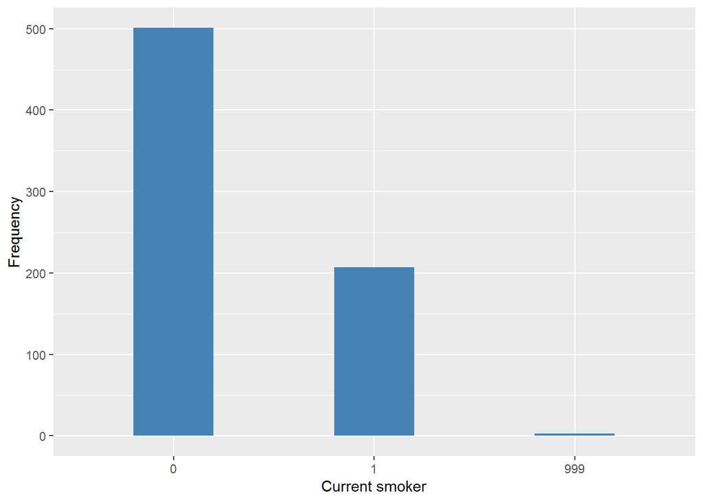

#### 2.4.2.4 Validation

|  | 0->0 | 1->1 | NA->999 |
| --- | --- | --- | --- |
| BeforeH | 501 | 207 | 3 |
| AfterH | 501 | 207 | 3 |

## 2.5 Dominican Republic

### 2.5.1 Wave 1

#### 2.5.1.1 Study-specific variable description

| **Name** | `PSMKNOW` |
| --- | --- |
| **Label** | `still smoking regularly?` |
| **Table name** | `1066-DominicanRepublic-Baseline` |
| **Categories** | `0 = No` `1 = Yes` |
| **Missings** | `NA` |
| **Description** |  |

PSMKNOW

| Sample size | Missing values |
| --- | --- |
| 2011 | 1051 |

Category

|  | 0 | 1 |
| --- | --- | --- |
| Frequency | 711.00 | 249.00 |
| Percentage | 35.36 | 12.38 |

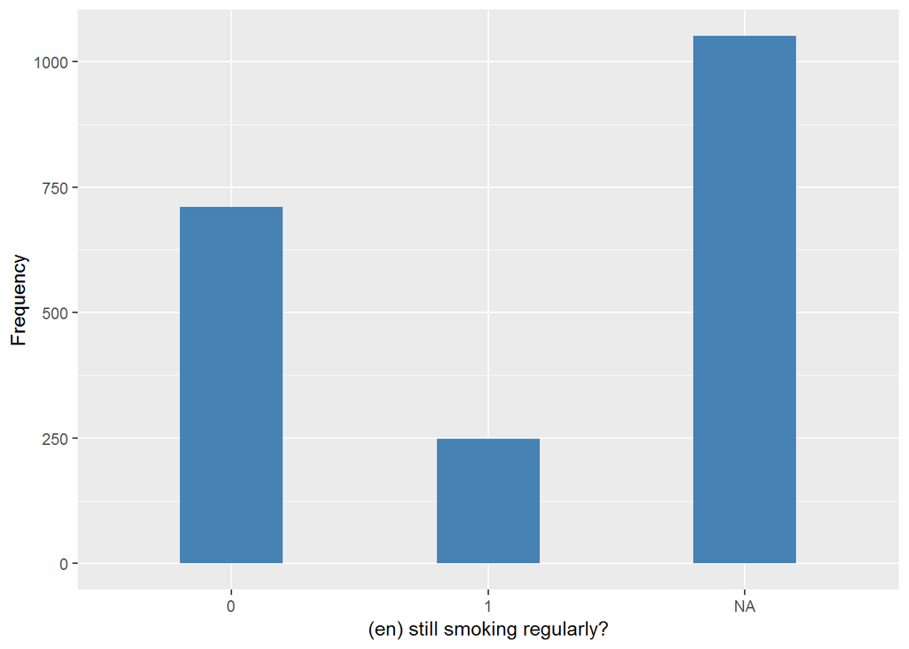

#### 2.5.1.2 Harmonisation algorithm

To compute the harmonize variable from the study-specific variable it has to be recoded as follows:

- `0 into 0`
- `1 into 1`
- `NA into 999`

```r
t1066_ds_DR_w1 <- tibble(id = t1066_DR_w1$id)
t1066_ds_DR_w1$current_smoking <- Recode(t1066_DR_w1$PSMKNOW, "0 = '0';1 ='1';NA='999'")
t1066_ds_DR_w1$current_smoking <- labelled(t1066_ds_DR_w1$current_smoking, labels = c(No = 0,
    Yes = 1, Missing = 999, Do_not_know = 998, Refuse = 997, Not_applicable = 996,
    Does_not_answer = 995, Not_attempt_not_done = 994, Disable_to_measure = 993,
    Impute = 992, CAPI_interviewer_error = 991))
```

#### 2.5.1.3 Statistical description of the new harmonised variable

Current smoker

| Sample size | Missing values |
| --- | --- |
| 2011 | 1051 |

Category

|  | 0 | 1 |
| --- | --- | --- |
| Frequency | 711.00 | 249.00 |
| Percentage | 35.36 | 12.38 |

Type of missing

|  | 991 | 992 | 993 | 994 | 995 | 996 | 997 | 998 | 999 | NA |
| --- | --- | --- | --- | --- | --- | --- | --- | --- | --- | --- |
| Frequency | 0 | 0 | 0 | 0 | 0 | 0 | 0 | 0 | 1051.00 | 0 |
| Percentage | 0 | 0 | 0 | 0 | 0 | 0 | 0 | 0 | 52.26 | 0 |

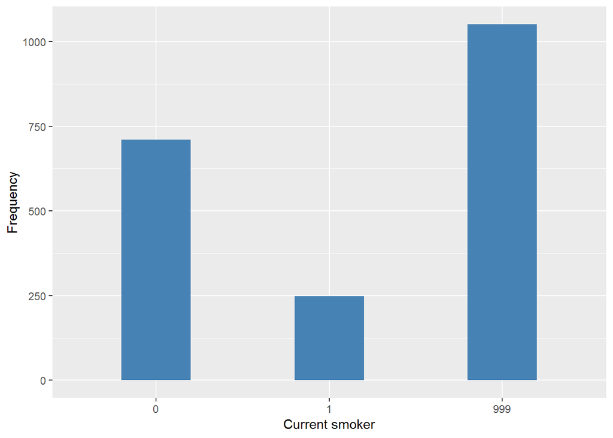

#### 2.5.1.4 Validation

|  | 0->0 | 1->1 | NA->999 |
| --- | --- | --- | --- |
| BeforeH | 711 | 249 | 1051 |
| AfterH | 711 | 249 | 1051 |

### 2.5.2 Wave 2

#### 2.5.2.1 Study-specific variable description

| **Name** | `f_PSMOKE1` |
| --- | --- |
| **Label** | `in the last week, did you smoke or use tobacco?` |
| **Table name** | `1066-DominicanRepublic-Followup` |
| **Categories** | `0 = No` `1 = Yes` |
| **Missings** | `NA` |
| **Description** |  |

f_PSMOKE1

| Sample size | Missing values |
| --- | --- |
| 1197 | 6 |

Category

|  | 0 | 1 |
| --- | --- | --- |
| Frequency | 1076.00 | 115.00 |
| Percentage | 89.89 | 9.61 |

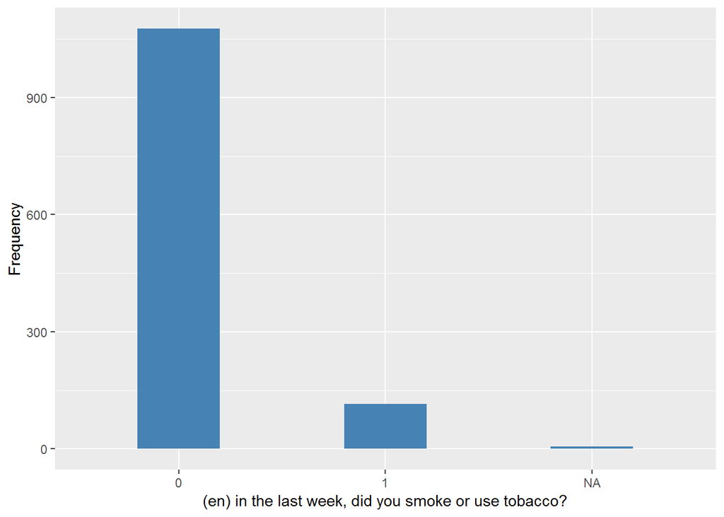

#### 2.5.2.2 Harmonisation algorithm

To compute the harmonize variable from the study-specific variable it has to be recoded as follows:

- `0 into 0`
- `1 into 1`
- `NA into 999`

```r
t1066_ds_DR_w2 <- tibble(id = t1066_DR_w2$id)
t1066_ds_DR_w2$current_smoking <- Recode(t1066_DR_w2$f_PSMOKE1, "0 = '0';1 ='1'; NA='999'")
t1066_ds_DR_w2$current_smoking <- labelled(t1066_ds_DR_w2$current_smoking, labels = c(No = 0,
    Yes = 1, Missing = 999, Do_not_know = 998, Refuse = 997, Not_applicable = 996,
    Does_not_answer = 995, Not_attempt_not_done = 994, Disable_to_measure = 993,
    Impute = 992, CAPI_interviewer_error = 991))
```

#### 2.5.2.3 Statistical description of the new harmonised variable

Current smoker

| Sample size | Missing values |
| --- | --- |
| 1197 | 6 |

Category

|  | 0 | 1 |
| --- | --- | --- |
| Frequency | 1076.00 | 115.00 |
| Percentage | 89.89 | 9.61 |

Type of missing

|  | 991 | 992 | 993 | 994 | 995 | 996 | 997 | 998 | 999 | NA |
| --- | --- | --- | --- | --- | --- | --- | --- | --- | --- | --- |
| Frequency | 0 | 0 | 0 | 0 | 0 | 0 | 0 | 0 | 6.0 | 0 |
| Percentage | 0 | 0 | 0 | 0 | 0 | 0 | 0 | 0 | 0.5 | 0 |

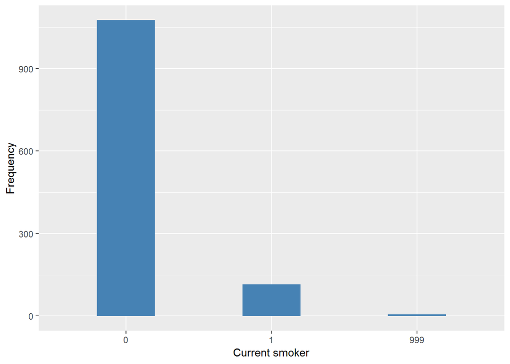

#### 2.5.2.4 Validation

|  | 0->0 | 1->1 | NA->999 |
| --- | --- | --- | --- |
| BeforeH | 1076 | 115 | 6 |
| AfterH | 1076 | 115 | 6 |

## 2.6 Venezuela

### 2.6.1 Wave 1

#### 2.6.1.1 Study-specific variable description

| **Name** | `PSMKNOW` |
| --- | --- |
| **Label** | `still smoking regularly?` |
| **Table name** | `1066-Venezuela-Baseline` |
| **Categories** | `0 = No` `1 = Yes` |
| **Missings** | `NA` |
| **Description** |  |

PSMKNOW

| Sample size | Missing values |
| --- | --- |
| 1965 | 1155 |

Category

|  | 0 | 1 |
| --- | --- | --- |
| Frequency | 595.00 | 215.00 |
| Percentage | 30.28 | 10.94 |

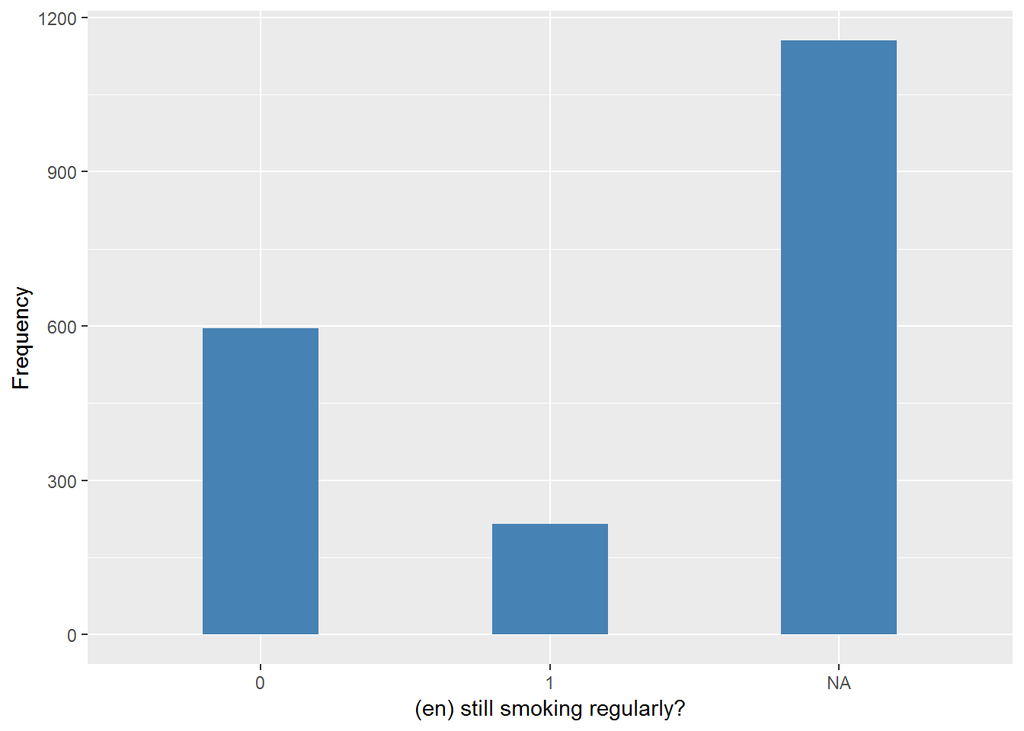

#### 2.6.1.2 Harmonisation algorithm

To compute the harmonize variable from the study-specific variable it has to be recoded as follows:

- `0 into 0`
- `1 into 1`
- `NA into 999`

```r
t1066_ds_Ven_w1 <- tibble(id = t1066_Ven_w1$id)
t1066_ds_Ven_w1$current_smoking <- Recode(t1066_Ven_w1$PSMKNOW, "0 = '0';1='1';NA='999'")
t1066_ds_Ven_w1$current_smoking <- labelled(t1066_ds_Ven_w1$current_smoking,
    labels = c(No = 0, Yes = 1, Missing = 999, Do_not_know = 998, Refuse = 997,
        Not_applicable = 996, Does_not_answer = 995, Not_attempt_not_done = 994,
        Disable_to_measure = 993, Impute = 992, CAPI_interviewer_error = 991))
```

#### 2.6.1.3 Statistical description of the new harmonised variable

Current smoker

| Sample size | Missing values |
| --- | --- |
| 1965 | 1155 |

Category

|  | 0 | 1 |
| --- | --- | --- |
| Frequency | 595.00 | 215.00 |
| Percentage | 30.28 | 10.94 |

Type of missing

|  | 991 | 992 | 993 | 994 | 995 | 996 | 997 | 998 | 999 | NA |
| --- | --- | --- | --- | --- | --- | --- | --- | --- | --- | --- |
| Frequency | 0 | 0 | 0 | 0 | 0 | 0 | 0 | 0 | 1155.00 | 0 |
| Percentage | 0 | 0 | 0 | 0 | 0 | 0 | 0 | 0 | 58.78 | 0 |

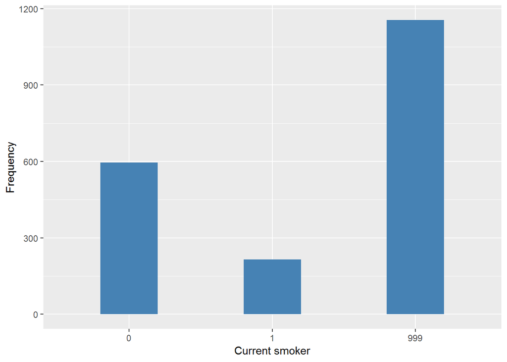

#### 2.6.1.4 Validation

|  | 0->0 | 1->1 | NA->999 |
| --- | --- | --- | --- |
| BeforeH | 595 | 215 | 1155 |
| AfterH | 595 | 215 | 1155 |

### 2.6.2 Wave 2

#### 2.6.2.1 Study-specific variable description

| **Name** | `f_PSMOKE1` |
| --- | --- |
| **Label** | `in the last week, did you smoke or use tobacco?` |
| **Table name** | `1066-Venezuela-Followup` |
| **Categories** | `0 = No` `1 = Yes` |
| **Missings** | `NA` |
| **Description** |  |

f_PSMOKE1

| Sample size | Missing values |
| --- | --- |
| 1257 | 4 |

Category

|  | 0 | 1 |
| --- | --- | --- |
| Frequency | 1154.00 | 99.00 |
| Percentage | 91.81 | 7.88 |

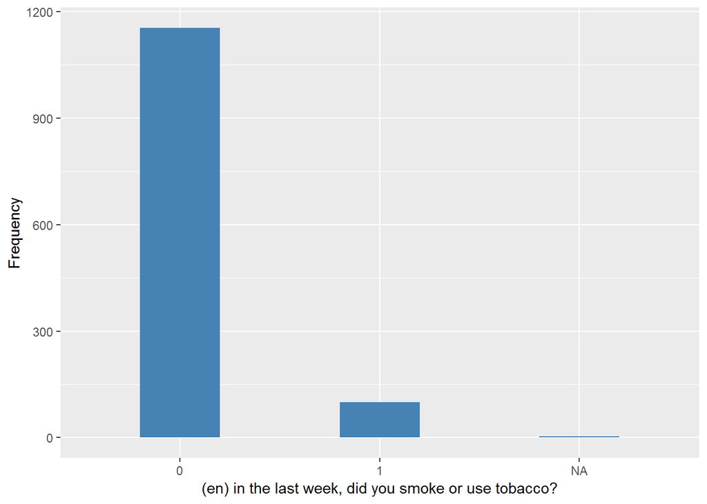

#### 2.6.2.2 Harmonisation algorithm

To compute the harmonize variable from the study-specific variable it has to be recoded as follows:

- `0 into 0`
- `1 into 1`
- `NA into 999`

```r
t1066_ds_Ven_w2 <- tibble(id = t1066_Ven_w2$id)
t1066_ds_Ven_w2$current_smoking <- Recode(t1066_Ven_w2$f_PSMOKE1, "0 = '0';1 ='1'; NA='999'")
t1066_ds_Ven_w2$current_smoking <- labelled(t1066_ds_Ven_w2$current_smoking,
    labels = c(No = 0, Yes = 1, Missing = 999, Do_not_know = 998, Refuse = 997,
        Not_applicable = 996, Does_not_answer = 995, Not_attempt_not_done = 994,
        Disable_to_measure = 993, Impute = 992, CAPI_interviewer_error = 991))
```

#### 2.6.2.3 Statistical description of the new harmonised variable

Current smoker

| Sample size | Missing values |
| --- | --- |
| 1257 | 4 |

Category

|  | 0 | 1 |
| --- | --- | --- |
| Frequency | 1154.00 | 99.00 |
| Percentage | 91.81 | 7.88 |

Type of missing

|  | 991 | 992 | 993 | 994 | 995 | 996 | 997 | 998 | 999 | NA |
| --- | --- | --- | --- | --- | --- | --- | --- | --- | --- | --- |
| Frequency | 0 | 0 | 0 | 0 | 0 | 0 | 0 | 0 | 4.00 | 0 |
| Percentage | 0 | 0 | 0 | 0 | 0 | 0 | 0 | 0 | 0.32 | 0 |

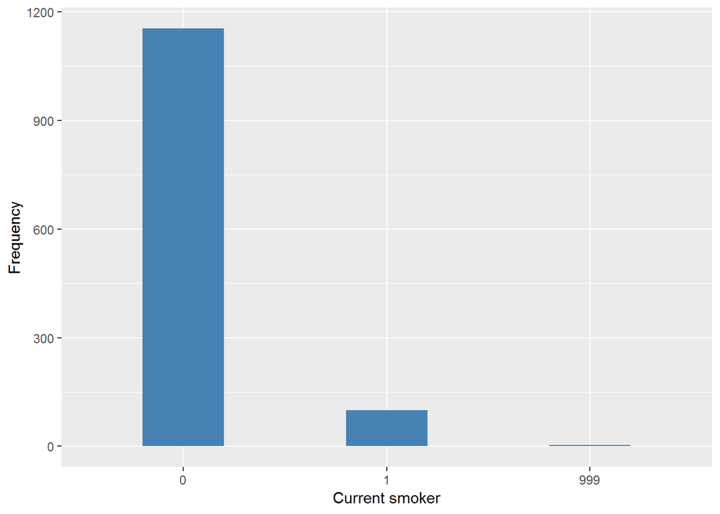

#### 2.6.2.4 Validation

|  | 0->0 | 1->1 | NA->999 |
| --- | --- | --- | --- |
| BeforeH | 1154 | 99 | 4 |
| AfterH | 1154 | 99 | 4 |

## 2.7 Urban Peru

### 2.7.1 Wave 1

#### 2.7.1.1 Study-specific variable description

| **Name** | `PSMKNOW` |
| --- | --- |
| **Label** | `still smoking regularly?` |
| **Table name** | `1066-UrbanPeru-Baseline` |
| **Categories** | `0 = No` `1 = Yes` |
| **Missings** | `NA` |
| **Description** |  |

PSMKNOW

| Sample size | Missing values |
| --- | --- |
| 1381 | 1126 |

Category

|  | 0 | 1 |
| --- | --- | --- |
| Frequency | 201.00 | 54.00 |
| Percentage | 14.55 | 3.91 |

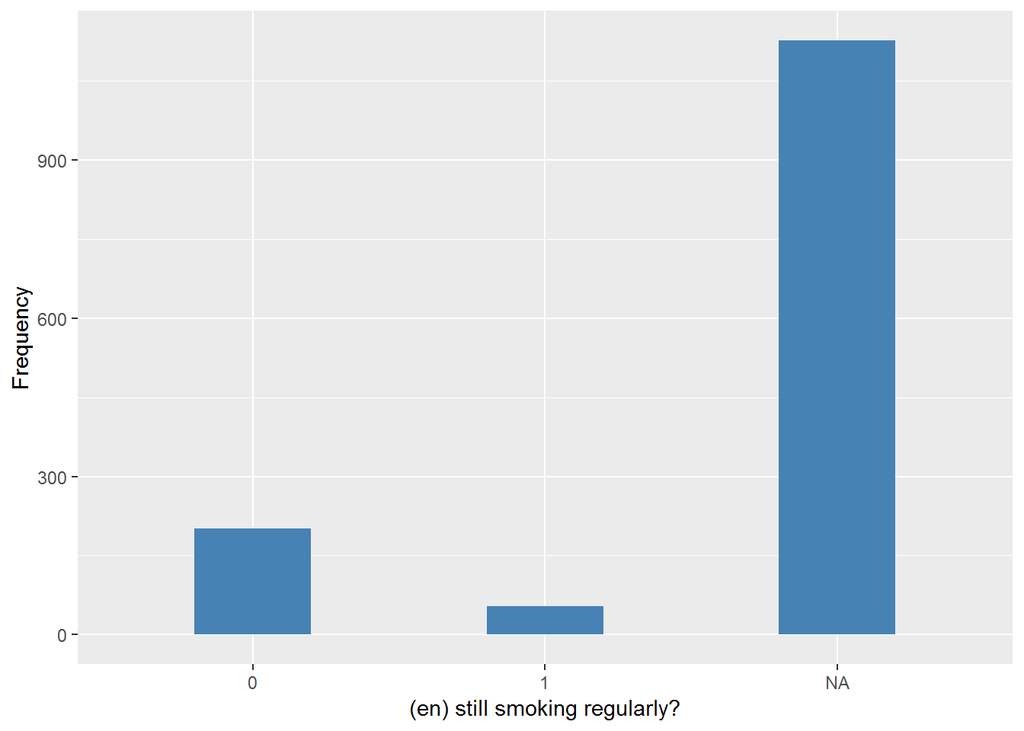

#### 2.7.1.2 Harmonisation algorithm

To compute the harmonize variable from the study-specific variable it has to be recoded as follows:

- `0 into 0`
- `1 into 1`
- `NA into 999`

```r
t1066_ds_UP_w1 <- tibble(id = t1066_UP_w1$id)
t1066_ds_UP_w1$current_smoking <- Recode(t1066_UP_w1$PSMKNOW, "0 = '0';1='1';NA='999'")
t1066_ds_UP_w1$current_smoking <- labelled(t1066_ds_UP_w1$current_smoking, labels = c(No = 0,
    Yes = 1, Missing = 999, Do_not_know = 998, Refuse = 997, Not_applicable = 996,
    Does_not_answer = 995, Not_attempt_not_done = 994, Disable_to_measure = 993,
    Impute = 992, CAPI_interviewer_error = 991))
```

#### 2.7.1.3 Statistical description of the new harmonised variable

current_smoking

| Sample size | Missing values |
| --- | --- |
| 1381 | 1126 |

Category

|  | 0 | 1 |
| --- | --- | --- |
| Frequency | 201.00 | 54.00 |
| Percentage | 14.55 | 3.91 |

Type of missing

|  | 991 | 992 | 993 | 994 | 995 | 996 | 997 | 998 | 999 | NA |
| --- | --- | --- | --- | --- | --- | --- | --- | --- | --- | --- |
| Frequency | 0 | 0 | 0 | 0 | 0 | 0 | 0 | 0 | 1126.00 | 0 |
| Percentage | 0 | 0 | 0 | 0 | 0 | 0 | 0 | 0 | 81.54 | 0 |

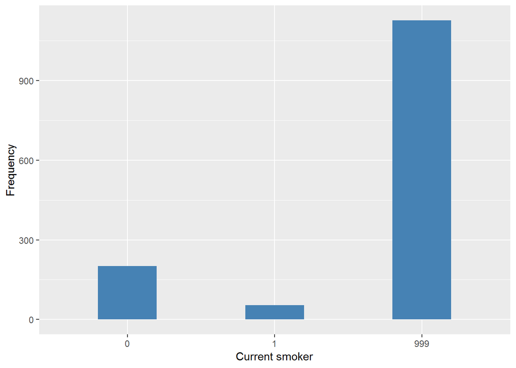

#### 2.7.1.4 Validation

|  | 0->0 | 1->1 | NA->999 |
| --- | --- | --- | --- |
| BeforeH | 201 | 54 | 1126 |
| AfterH | 201 | 54 | 1126 |

### 2.7.2 Wave 2

#### 2.7.2.1 Study-specific variable description

| **Name** | `f_PSMOKE1` |
| --- | --- |
| **Label** | `in the last week, did you smoke or use tobacco?` |
| **Table name** | `1066-UrbanPeru-Followup` |
| **Categories** | `0 = No` `1 = Yes` |
| **Missings** |  |
| **Description** |  |

f_PSMOKE1

| Sample size | Missing values |
| --- | --- |
| 890 | 0 |

Category

|  | 0 | 1 |
| --- | --- | --- |
| Frequency | 856.00 | 34.00 |
| Percentage | 96.18 | 3.82 |

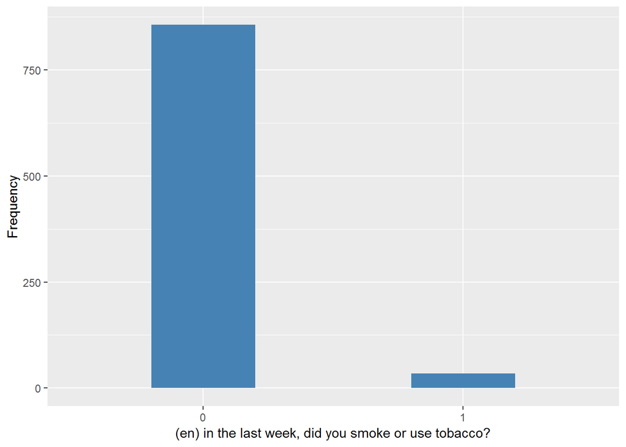

#### 2.7.2.2 Harmonisation algorithm

To compute the harmonize variable from the study-specific variable it has to be recoded as follows:

- `0 into 0`
- `1 into 1`
- `NA into 999`

```r
t1066_ds_UP_w2 <- tibble(id = t1066_UP_w2$id)
t1066_ds_UP_w2$current_smoking <- Recode(t1066_UP_w2$f_PSMOKE1, "0 = '0';1='1'; NA='999'")
t1066_ds_UP_w2$current_smoking <- labelled(t1066_ds_UP_w2$current_smoking, labels = c(No = 0,
    Yes = 1, Missing = 999, Do_not_know = 998, Refuse = 997, Not_applicable = 996,
    Does_not_answer = 995, Not_attempt_not_done = 994, Disable_to_measure = 993,
    Impute = 992, CAPI_interviewer_error = 991))
```

#### 2.7.2.3 Statistical description of the new harmonised variable

Current smoker

| Sample size | Missing values |
| --- | --- |
| 890 | 0 |

Category

|  | 0 | 1 |
| --- | --- | --- |
| Frequency | 856.00 | 34.00 |
| Percentage | 96.18 | 3.82 |

Type of missing

|  | 991 | 992 | 993 | 994 | 995 | 996 | 997 | 998 | 999 | NA |
| --- | --- | --- | --- | --- | --- | --- | --- | --- | --- | --- |
| Frequency | 0 | 0 | 0 | 0 | 0 | 0 | 0 | 0 | 0 | 0 |
| Percentage | 0 | 0 | 0 | 0 | 0 | 0 | 0 | 0 | 0 | 0 |

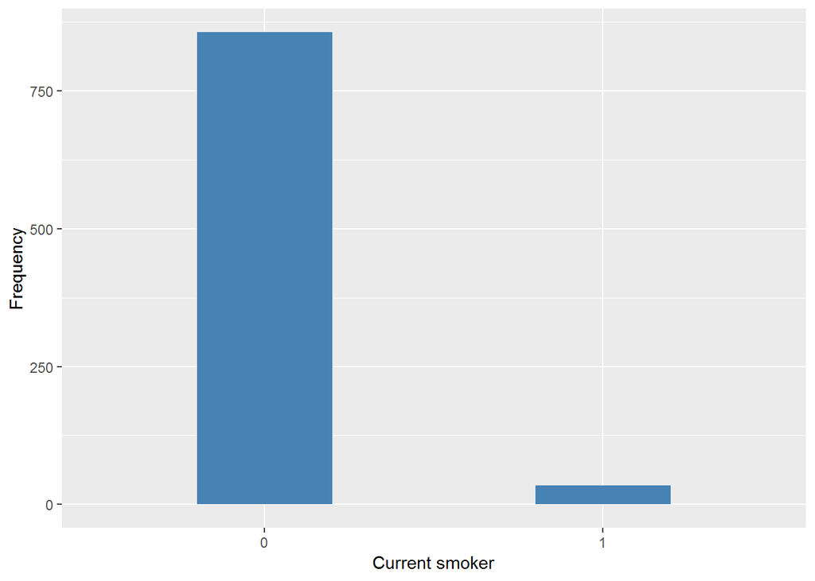

#### 2.7.2.4 Validation

|  | 0->0 | 1->1 |
| --- | --- | --- |
| BeforeH | 856 | 34 |
| AfterH | 856 | 34 |

## 2.8 Rural Peru

### 2.8.1 Wave 1

#### 2.8.1.1 Study-specific variable description

| **Name** | `PSMKNOW` |
| --- | --- |
| **Label** | `still smoking regularly?` |
| **Table name** | `1066-RuralPeru-Baseline` |
| **Categories** | `0 = No` `1 = Yes` |
| **Missings** | `NA` |
| **Description** |  |

PSMKNOW

| Sample size | Missing values |
| --- | --- |
| 552 | 484 |

Category

|  | 0 | 1 |
| --- | --- | --- |
| Frequency | 54.00 | 14.00 |
| Percentage | 9.78 | 2.54 |

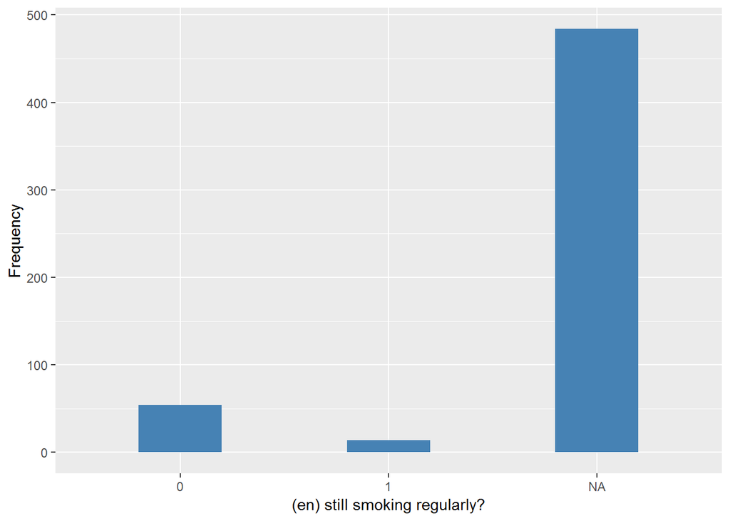

#### 2.8.1.2 Harmonisation algorithm

To compute the harmonize variable from the study-specific variable it has to be recoded as follows:

- `0 into 0`
- `1 into 1`
- `NA into 999`

```r
t1066_ds_RP_w1 <- tibble(id = t1066_RP_w1$id)
t1066_ds_RP_w1$current_smoking <- Recode(t1066_RP_w1$PSMKNOW, "0 = '0';1 ='1'; NA = '999'")
t1066_ds_RP_w1$current_smoking <- labelled(t1066_ds_RP_w1$current_smoking, labels = c(No = 0,
    Yes = 1, Missing = 999, Do_not_know = 998, Refuse = 997, Not_applicable = 996,
    Does_not_answer = 995, Not_attempt_not_done = 994, Disable_to_measure = 993,
    Impute = 992, CAPI_interviewer_error = 991))
```

#### 2.8.1.3 Statistical description of the new harmonised variable

Current smoker

| Sample size | Missing values |
| --- | --- |
| 552 | 484 |

Category

|  | 0 | 1 |
| --- | --- | --- |
| Frequency | 54.00 | 14.00 |
| Percentage | 9.78 | 2.54 |

Type of missing

|  | 991 | 992 | 993 | 994 | 995 | 996 | 997 | 998 | 999 | NA |
| --- | --- | --- | --- | --- | --- | --- | --- | --- | --- | --- |
| Frequency | 0 | 0 | 0 | 0 | 0 | 0 | 0 | 0 | 484.00 | 0 |
| Percentage | 0 | 0 | 0 | 0 | 0 | 0 | 0 | 0 | 87.68 | 0 |

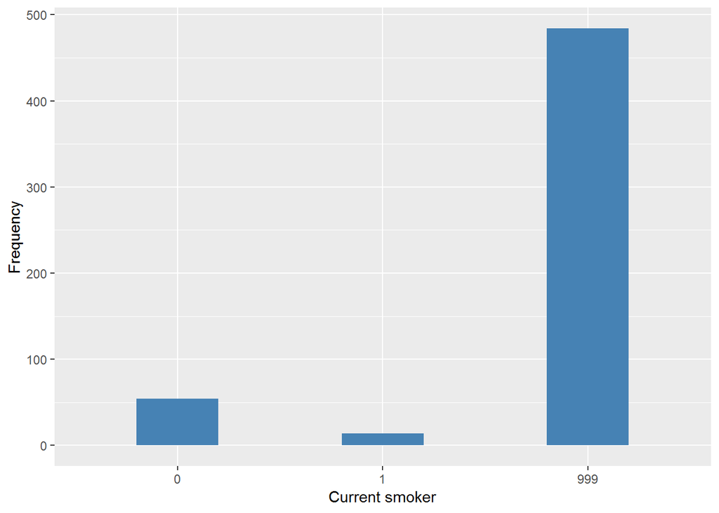

#### 2.8.1.4 Validation

|  | 0->0 | 1->1 | NA->999 |
| --- | --- | --- | --- |
| BeforeH | 54 | 14 | 484 |
| AfterH | 54 | 14 | 484 |

### 2.8.2 Wave 2

#### 2.8.2.1 Study-specific variable description

| **Name** | `f_PSMOKE1` |
| --- | --- |
| **Label** | `in the last week, did you smoke or use tobacco?` |
| **Table name** | `1066-RuralPeru-Followup` |
| **Categories** | `0 = No` `1 = Yes` |
| **Missings** |  |
| **Description** |  |

f_PSMOKE1

| Sample size | Missing values |
| --- | --- |
| 421 | 0 |

Category

|  | 0 | 1 |
| --- | --- | --- |
| Frequency | 415.00 | 6.00 |
| Percentage | 98.57 | 1.43 |

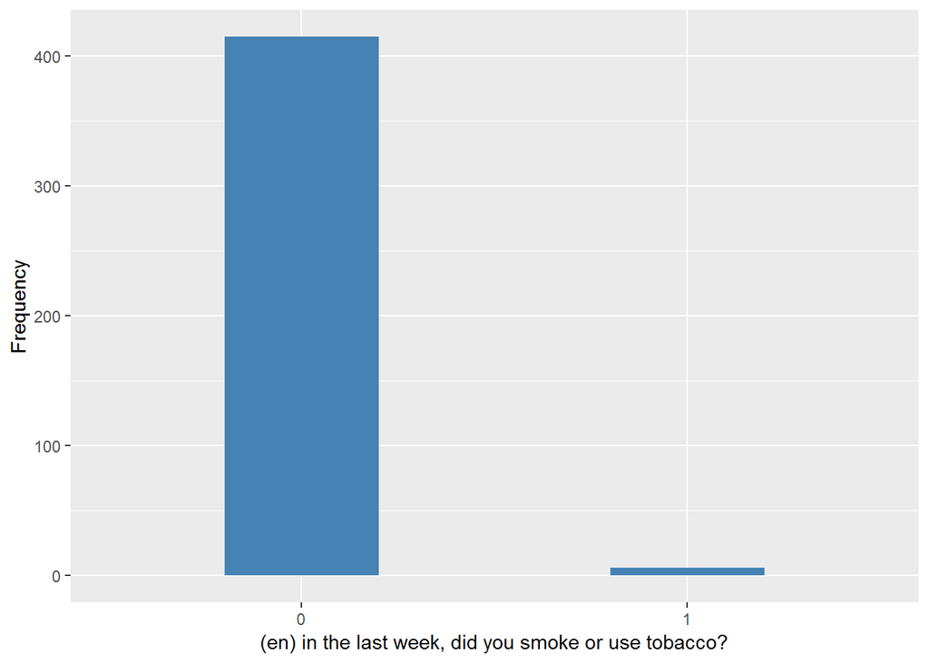

#### 2.8.2.2 Harmonisation algorithm

To compute the harmonize variable from the study-specific variable it has to be recoded as follows:

- `0 into 0`
- `1 into 1`

```r
t1066_ds_RP_w2 <- tibble(id = t1066_RP_w2$id)
t1066_ds_RP_w2$current_smoking <- Recode(t1066_RP_w2$f_PSMOKE1, "0 = '0';1 ='1'")
t1066_ds_RP_w2$current_smoking <- labelled(t1066_ds_RP_w2$current_smoking, labels = c(No = 0,
    Yes = 1, Missing = 999, Do_not_know = 998, Refuse = 997, Not_applicable = 996,
    Does_not_answer = 995, Not_attempt_not_done = 994, Disable_to_measure = 993,
    Impute = 992, CAPI_interviewer_error = 991))
```

#### 2.8.2.3 Statistical description of the new harmonised variable

Current smoker

| Sample size | Missing values |
| --- | --- |
| 421 | 0 |

Category

|  | 0 | 1 |
| --- | --- | --- |
| Frequency | 415.00 | 6.00 |
| Percentage | 98.57 | 1.43 |

Type of missing

|  | 991 | 992 | 993 | 994 | 995 | 996 | 997 | 998 | 999 | NA |
| --- | --- | --- | --- | --- | --- | --- | --- | --- | --- | --- |
| Frequency | 0 | 0 | 0 | 0 | 0 | 0 | 0 | 0 | 0 | 0 |
| Percentage | 0 | 0 | 0 | 0 | 0 | 0 | 0 | 0 | 0 | 0 |

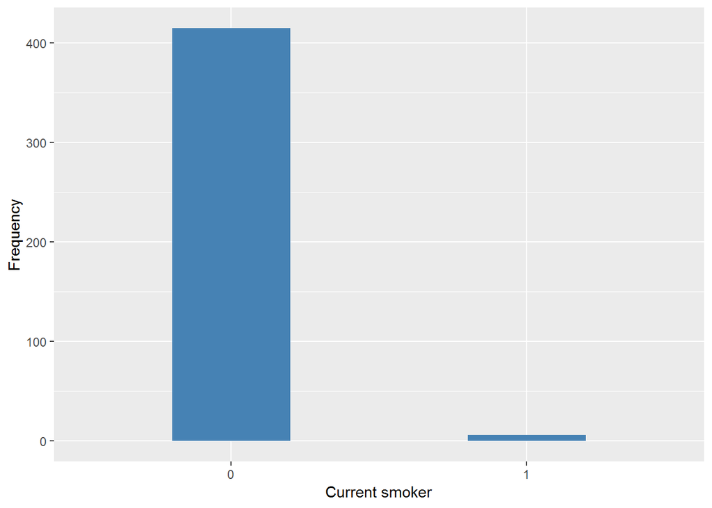

#### 2.8.2.4 Validation

|  | 0->0 | 1->1 |
| --- | --- | --- |
| BeforeH | 415 | 6 |
| AfterH | 415 | 6 |

## 2.9 Urban Mexico

### 2.9.1 Wave 1

#### 2.9.1.1 Study-specific variable description

| **Name** | `PSMKNOW` |
| --- | --- |
| **Label** | `still smoking regularly?` |
| **Table name** | `1066-UrbanMexico-Baseline` |
| **Categories** | `0 = No` `1 = Yes` |
| **Missings** | `NA` |
| **Description** |  |

PSMKNOW

| Sample size | Missing values |
| --- | --- |
| 1003 | 648 |

Category

|  | 0 | 1 |
| --- | --- | --- |
| Frequency | 246.00 | 109.00 |
| Percentage | 24.53 | 10.87 |

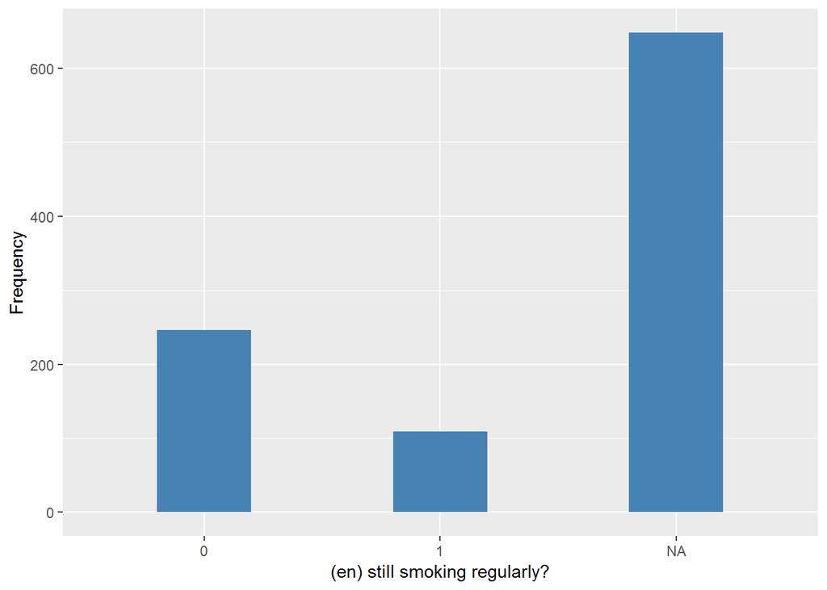

#### 2.9.1.2 Harmonisation algorithm

To compute the harmonize variable from the study-specific variable it has to be recoded as follows:

- `0 into 0`
- `1 into 1`
- `NA into 999`

```r
t1066_ds_UM_w1 <- tibble(id = t1066_UM_w1$id)
t1066_ds_UM_w1$current_smoking <- Recode(t1066_UM_w1$PSMKNOW, "0 = '0';1='1';NA='999'")
t1066_ds_UM_w1$current_smoking <- labelled(t1066_ds_UM_w1$current_smoking, labels = c(No = 0,
    Yes = 1, Missing = 999, Do_not_know = 998, Refuse = 997, Not_applicable = 996,
    Does_not_answer = 995, Not_attempt_not_done = 994, Disable_to_measure = 993,
    Impute = 992, CAPI_interviewer_error = 991))
```

#### 2.9.1.3 Statistical description of the new harmonised variable

Current smoker

| Sample size | Missing values |
| --- | --- |
| 1003 | 648 |

Category

|  | 0 | 1 |
| --- | --- | --- |
| Frequency | 246.00 | 109.00 |
| Percentage | 24.53 | 10.87 |

Type of missing

|  | 991 | 992 | 993 | 994 | 995 | 996 | 997 | 998 | 999 | NA |
| --- | --- | --- | --- | --- | --- | --- | --- | --- | --- | --- |
| Frequency | 0 | 0 | 0 | 0 | 0 | 0 | 0 | 0 | 648.00 | 0 |
| Percentage | 0 | 0 | 0 | 0 | 0 | 0 | 0 | 0 | 64.61 | 0 |

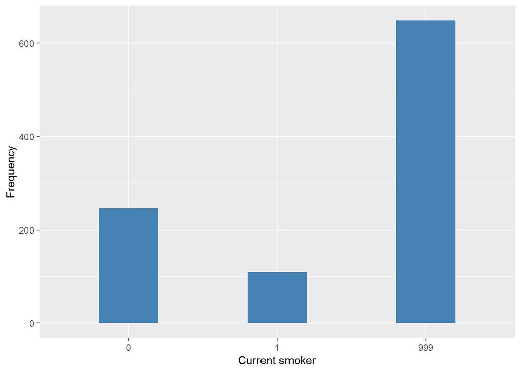

#### 2.9.1.4 Validation

|  | 0->0 | 1->1 | NA->999 |
| --- | --- | --- | --- |
| BeforeH | 246 | 109 | 648 |
| AfterH | 246 | 109 | 648 |

### 2.9.2 Wave 2

#### 2.9.2.1 Study-specific variable description

| **Name** | `f_PSMOKE1` |
| --- | --- |
| **Label** | `in the last week, did you smoke or use tobacco?` |
| **Table name** | `1066-UrbanMexico-Followup` |
| **Categories** | `0 = No` `1 = Yes` |
| **Missings** | `NA` |
| **Description** |  |

f_PSMOKE1

| Sample size | Missing values |
| --- | --- |
| 749 | 1 |

Category

|  | 0 | 1 |
| --- | --- | --- |
| Frequency | 685.00 | 63.00 |
| Percentage | 91.46 | 8.41 |

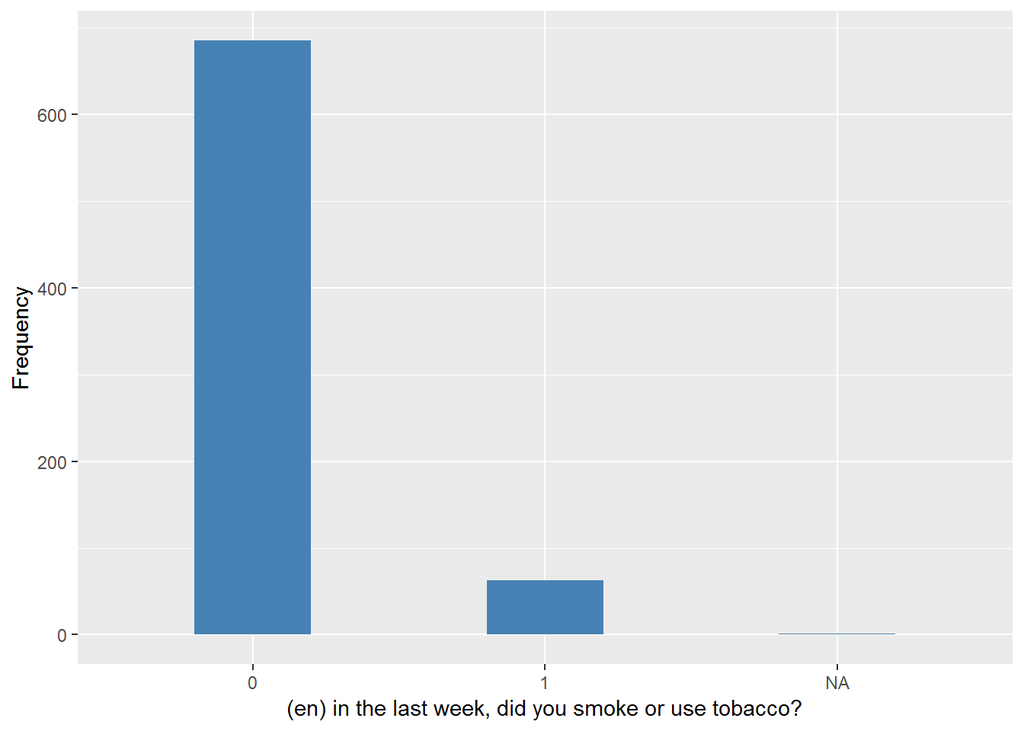

#### 2.9.2.2 Harmonisation algorithm

To compute the harmonize variable from the study-specific variable it has to be recoded as follows:

- `0 into 0`
- `1 into 1`
- `NA into 999`

```r
t1066_ds_UM_w2 <- tibble(id = t1066_UM_w2$id)
t1066_ds_UM_w2$current_smoking <- Recode(t1066_UM_w2$f_PSMOKE1, "0 = '0';1='1'; NA='999'")
t1066_ds_UM_w2$current_smoking <- labelled(t1066_ds_UM_w2$current_smoking, labels = c(No = 0,
    Yes = 1, Missing = 999, Do_not_know = 998, Refuse = 997, Not_applicable = 996,
    Does_not_answer = 995, Not_attempt_not_done = 994, Disable_to_measure = 993,
    Impute = 992, CAPI_interviewer_error = 991))
```

#### 2.9.2.3 Statistical description of the new harmonised variable

Current smoker

| Sample size | Missing values |
| --- | --- |
| 749 | 1 |

Category

|  | 0 | 1 |
| --- | --- | --- |
| Frequency | 685.00 | 63.00 |
| Percentage | 91.46 | 8.41 |

Type of missing

|  | 991 | 992 | 993 | 994 | 995 | 996 | 997 | 998 | 999 | NA |
| --- | --- | --- | --- | --- | --- | --- | --- | --- | --- | --- |
| Frequency | 0 | 0 | 0 | 0 | 0 | 0 | 0 | 0 | 1.00 | 0 |
| Percentage | 0 | 0 | 0 | 0 | 0 | 0 | 0 | 0 | 0.13 | 0 |

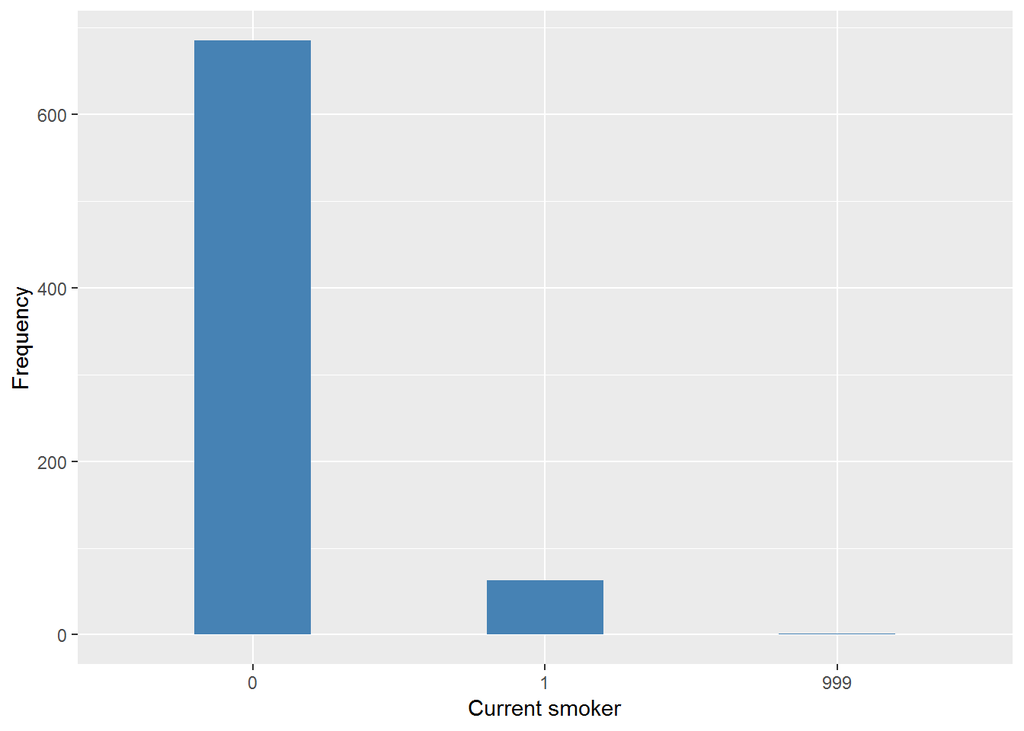

#### 2.9.2.4 Validation

|  | 0->0 | 1->1 | NA->999 |
| --- | --- | --- | --- |
| BeforeH | 685 | 63 | 1 |
| AfterH | 685 | 63 | 1 |

## 2.10 Rural Mexico

### 2.10.1 Wave 1

#### 2.10.1.1 Study-specific variable description

| **Name** | `PSMKNOW` |
| --- | --- |
| **Label** | `still smoking regularly?` |
| **Table name** | `1066-RuralMexico-Baseline` |
| **Categories** | `0 = No` `1 = Yes` |
| **Missings** | `NA` |
| **Description** |  |

PSMKNOW

| Sample size | Missing values |
| --- | --- |
| 1000 | 729 |

Category

|  | 0 | 1 |
| --- | --- | --- |
| Frequency | 200 | 71.0 |
| Percentage | 20 | 7.1 |

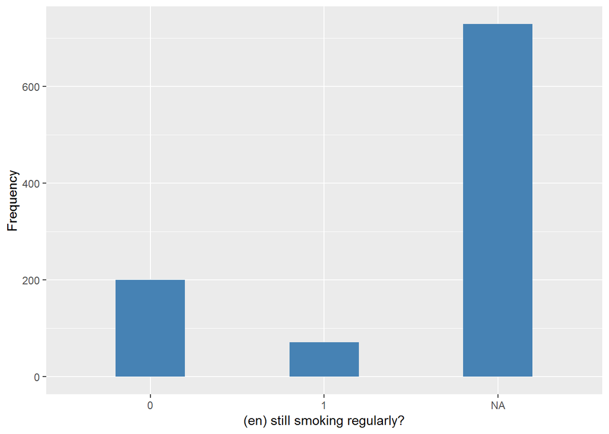

#### 2.10.1.2 Harmonisation algorithm

To compute the harmonize variable from the study-specific variable it has to be recoded as follows:

- `0 into 0`
- `1 into 1`
- `NA into 999`

```r
t1066_ds_RM_w1 <- tibble(id = t1066_RM_w1$id)
t1066_ds_RM_w1$current_smoking <- Recode(t1066_RM_w1$PSMKNOW, "0 = '0';1 ='1';NA='999'")
t1066_ds_RM_w1$current_smoking <- labelled(t1066_ds_RM_w1$current_smoking, labels = c(No = 0,
    Yes = 1, Missing = 999, Do_not_know = 998, Refuse = 997, Not_applicable = 996,
    Does_not_answer = 995, Not_attempt_not_done = 994, Disable_to_measure = 993,
    Impute = 992, CAPI_interviewer_error = 991))
```

#### 2.10.1.3 Statistical description of the new harmonised variable

Current smoker

| Sample size | Missing values |
| --- | --- |
| 1000 | 729 |

Category

|  | 0 | 1 |
| --- | --- | --- |
| Frequency | 200 | 71.0 |
| Percentage | 20 | 7.1 |

Type of missing

|  | 991 | 992 | 993 | 994 | 995 | 996 | 997 | 998 | 999 | NA |
| --- | --- | --- | --- | --- | --- | --- | --- | --- | --- | --- |
| Frequency | 0 | 0 | 0 | 0 | 0 | 0 | 0 | 0 | 729.0 | 0 |
| Percentage | 0 | 0 | 0 | 0 | 0 | 0 | 0 | 0 | 72.9 | 0 |

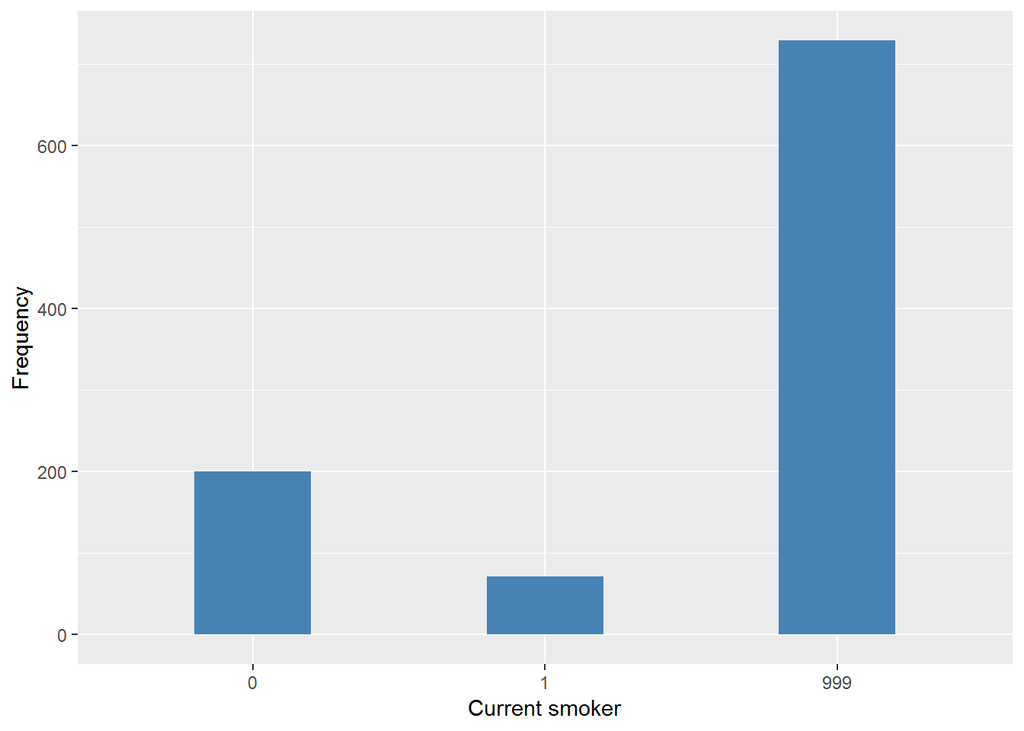

#### 2.10.1.4 Validation

|  | 0->0 | 1->1 | NA->999 |
| --- | --- | --- | --- |
| BeforeH | 200 | 71 | 729 |
| AfterH | 200 | 71 | 729 |

### 2.10.2 Wave 2

#### 2.10.2.1 Study-specific variable description

| **Name** | `f_PSMOKE1` |
| --- | --- |
| **Label** | `in the last week, did you smoke or use tobacco?` |
| **Table name** | `1066-RuralMexico-Followup` |
| **Categories** | `0 = No` `1 = Yes` |
| **Missings** | `NA` |
| **Description** |  |

f_PSMOKE1

| Sample size | Missing values |
| --- | --- |
| 713 | 2 |

Category

|  | 0 | 1 |
| --- | --- | --- |
| Frequency | 686.00 | 25.00 |
| Percentage | 96.21 | 3.51 |

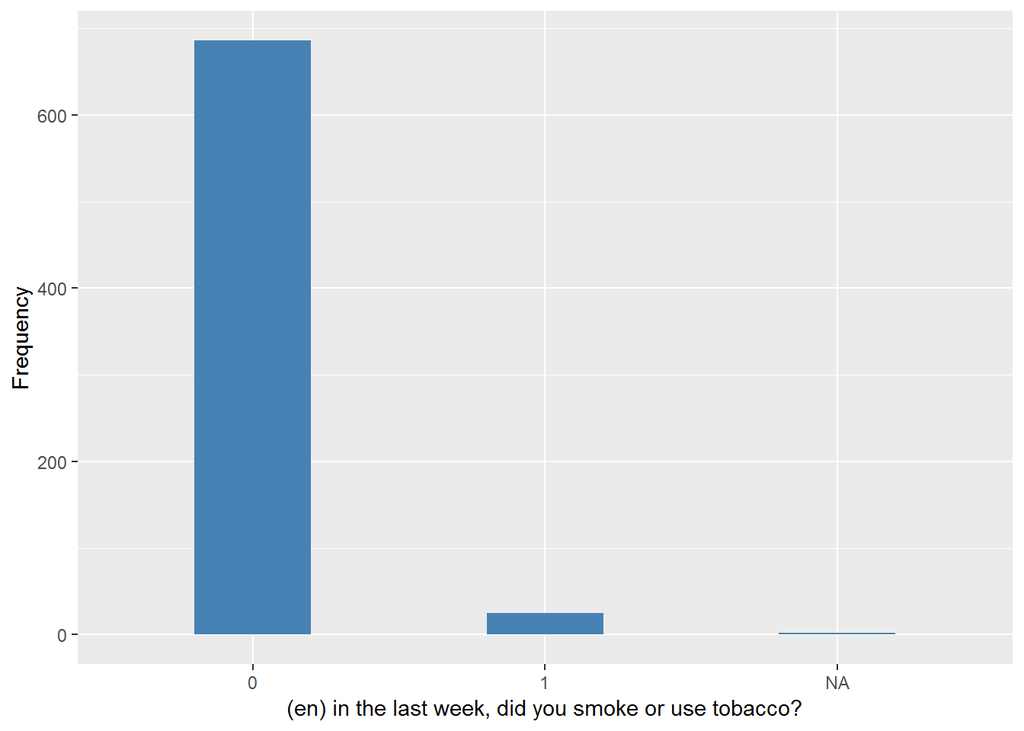

#### 2.10.2.2 Harmonisation algorithm

To compute the harmonize variable from the study-specific variable it has to be recoded as follows:

- `0 into 0`
- `1 into 1`
- `NA into 999`

```r
t1066_ds_RM_w2 <- tibble(id = t1066_RM_w2$id)
t1066_ds_RM_w2$current_smoking <- Recode(t1066_RM_w2$f_PSMOKE1, "0 = '0';1='1'; NA='999'")
t1066_ds_RM_w2$current_smoking <- labelled(t1066_ds_RM_w2$current_smoking, labels = c(No = 0,
    Yes = 1, Missing = 999, Do_not_know = 998, Refuse = 997, Not_applicable = 996,
    Does_not_answer = 995, Not_attempt_not_done = 994, Disable_to_measure = 993,
    Impute = 992, CAPI_interviewer_error = 991))
```

#### 2.10.2.3 Statistical description of the new harmonised variable

Current smoker

| Sample size | Missing values |
| --- | --- |
| 713 | 2 |

Category

|  | 0 | 1 |
| --- | --- | --- |
| Frequency | 686.00 | 25.00 |
| Percentage | 96.21 | 3.51 |

Type of missing

|  | 991 | 992 | 993 | 994 | 995 | 996 | 997 | 998 | 999 | NA |
| --- | --- | --- | --- | --- | --- | --- | --- | --- | --- | --- |
| Frequency | 0 | 0 | 0 | 0 | 0 | 0 | 0 | 0 | 2.00 | 0 |
| Percentage | 0 | 0 | 0 | 0 | 0 | 0 | 0 | 0 | 0.28 | 0 |

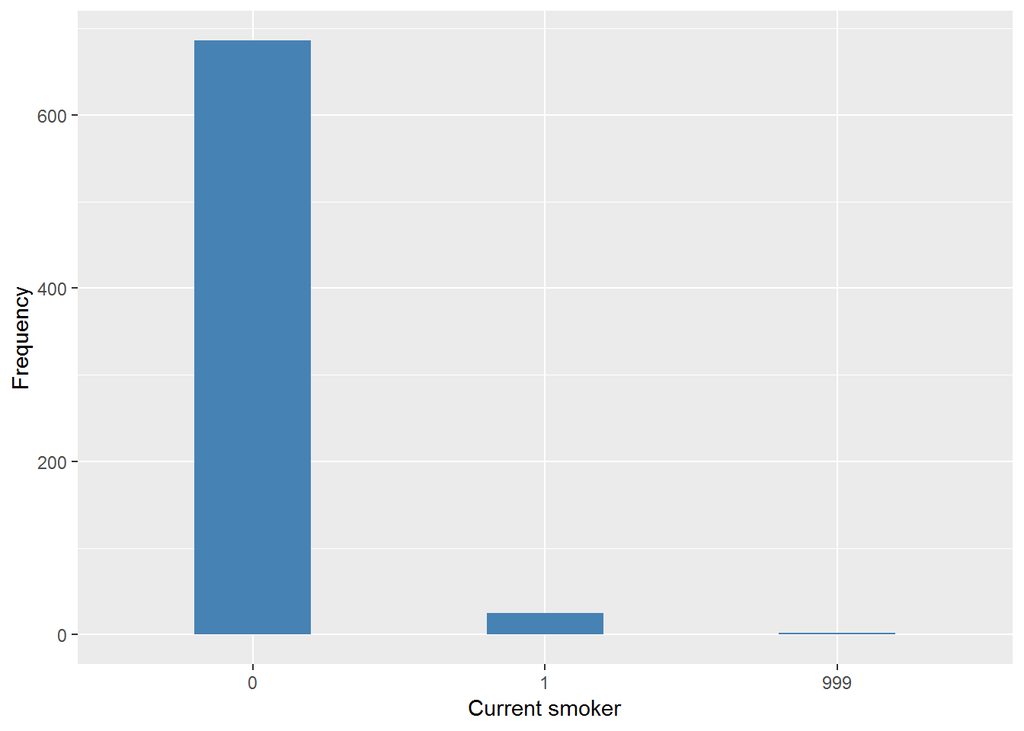

#### 2.10.2.4 Validation

|  | 0->0 | 1->1 | NA->999 |
| --- | --- | --- | --- |
| BeforeH | 686 | 25 | 2 |
| AfterH | 686 | 25 | 2 |

## 2.11 Puerto Rico

### 2.11.1 Wave 1

#### 2.11.1.1 Study-specific variable description

| **Name** | `PSMKNOW` |
| --- | --- |
| **Label** | `still smoking regularly?` |
| **Table name** | `1066-PuertoRico-Baseline` |
| **Categories** | `0 = No` `1 = Yes` |
| **Missings** | `NA` |
| **Description** |  |

PSMKNOW

| Sample size | Missing values |
| --- | --- |
| 2009 | 1447 |

Category

|  | 0 | 1 |
| --- | --- | --- |
| Frequency | 458.0 | 104.00 |
| Percentage | 22.8 | 5.18 |

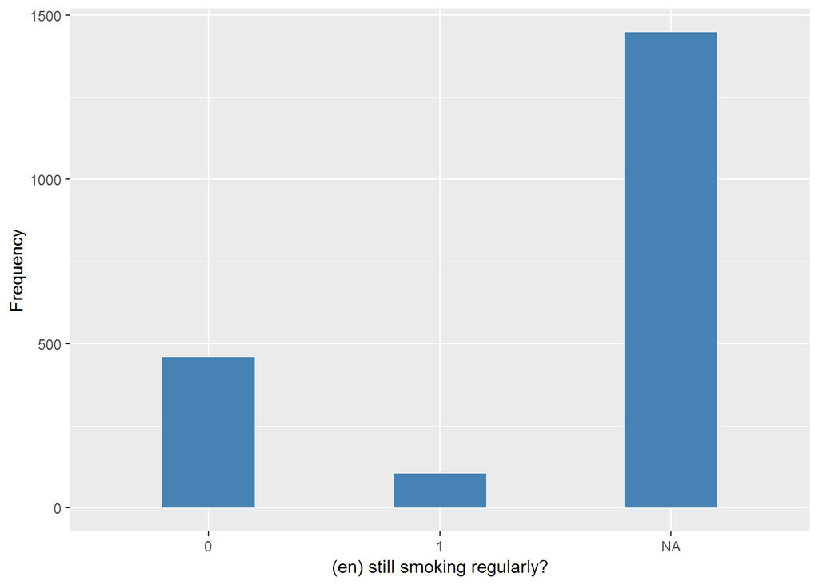

#### 2.11.1.2 Harmonisation algorithm

To compute the harmonize variable from the study-specific variable it has to be recoded as follows:

- `0 into 0`
- `1 into 1`
- `NA into 999`

```r
t1066_ds_PR_w1 <- tibble(id = t1066_PR_w1$id)
t1066_ds_PR_w1$current_smoking <- Recode(t1066_PR_w1$PSMKNOW, "0 = '0';1 ='1';NA = '999'")
t1066_ds_PR_w1$current_smoking <- labelled(t1066_ds_PR_w1$current_smoking, labels = c(No = 0,
    Yes = 1, Missing = 999, Do_not_know = 998, Refuse = 997, Not_applicable = 996,
    Does_not_answer = 995, Not_attempt_not_done = 994, Disable_to_measure = 993,
    Impute = 992, CAPI_interviewer_error = 991))
```

#### 2.11.1.3 Statistical description of the new harmonised variable

Current smoker

| Sample size | Missing values |
| --- | --- |
| 2009 | 1447 |

Category

|  | 0 | 1 |
| --- | --- | --- |
| Frequency | 458.0 | 104.00 |
| Percentage | 22.8 | 5.18 |

Type of missing

|  | 991 | 992 | 993 | 994 | 995 | 996 | 997 | 998 | 999 | NA |
| --- | --- | --- | --- | --- | --- | --- | --- | --- | --- | --- |
| Frequency | 0 | 0 | 0 | 0 | 0 | 0 | 0 | 0 | 1447.00 | 0 |
| Percentage | 0 | 0 | 0 | 0 | 0 | 0 | 0 | 0 | 72.03 | 0 |

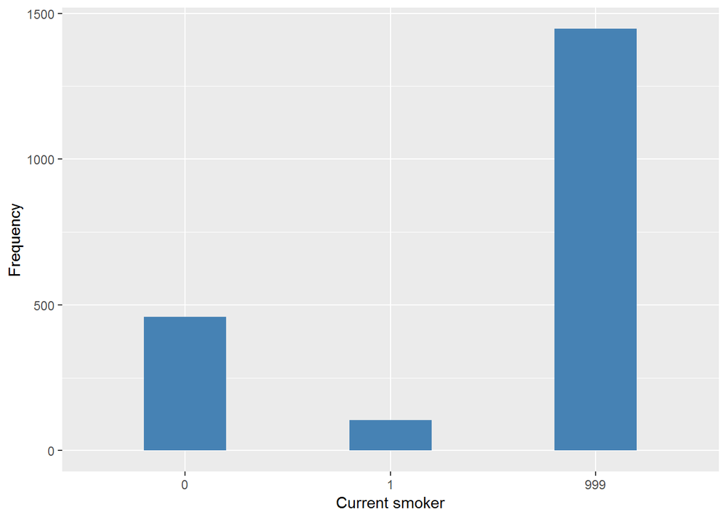

#### 2.11.1.4 Validation

|  | 0->0 | 1->1 | NA->999 |
| --- | --- | --- | --- |
| BeforeH | 458 | 104 | 1447 |
| AfterH | 458 | 104 | 1447 |

### 2.11.2 Wave 2

#### 2.11.2.1 Study-specific variable description

| **Name** | `f_PSMOKE1` |
| --- | --- |
| **Label** | `in the last week, did you smoke or use tobacco?` |
| **Table name** | `1066-PuertoRico-Followup` |
| **Categories** | `0 = No` `1 = Yes` |
| **Missings** | `NA` |
| **Description** |  |

f_PSMOKE1

| Sample size | Missing values |
| --- | --- |
| 1265 | 11 |

Category

|  | 0 | 1 |
| --- | --- | --- |
| Frequency | 1224.00 | 30.00 |
| Percentage | 96.76 | 2.37 |

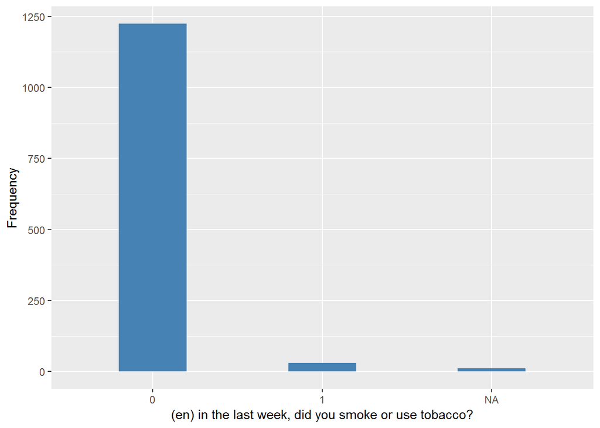

#### 2.11.2.2 Harmonisation algorithm

To compute the harmonize variable from the study-specific variable it has to be recoded as follows:

- `0 into 0`
- `1 into 1`
- `NA into 999`

```r
t1066_ds_PR_w2 <- tibble(id = t1066_PR_w2$id)
t1066_ds_PR_w2$current_smoking <- Recode(t1066_PR_w2$f_PSMOKE1, "0 = '0';1 ='1'; NA='999'")
t1066_ds_PR_w2$current_smoking <- labelled(t1066_ds_PR_w2$current_smoking, labels = c(No = 0,
    Yes = 1, Missing = 999, Do_not_know = 998, Refuse = 997, Not_applicable = 996,
    Does_not_answer = 995, Not_attempt_not_done = 994, Disable_to_measure = 993,
    Impute = 992, CAPI_interviewer_error = 991))
```

#### 2.11.2.3 Statistical description of the new harmonised variable

Current smoker

| Sample size | Missing values |
| --- | --- |
| 1265 | 11 |

Category

|  | 0 | 1 |
| --- | --- | --- |
| Frequency | 1224.00 | 30.00 |
| Percentage | 96.76 | 2.37 |

Type of missing

|  | 991 | 992 | 993 | 994 | 995 | 996 | 997 | 998 | 999 | NA |
| --- | --- | --- | --- | --- | --- | --- | --- | --- | --- | --- |
| Frequency | 0 | 0 | 0 | 0 | 0 | 0 | 0 | 0 | 11.00 | 0 |
| Percentage | 0 | 0 | 0 | 0 | 0 | 0 | 0 | 0 | 0.87 | 0 |

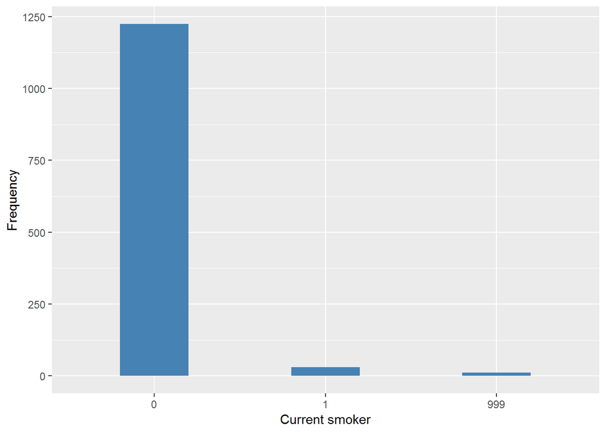

#### 2.11.2.4 Validation

|  | 0->0 | 1->1 | NA->999 |
| --- | --- | --- | --- |
| BeforeH | 1224 | 30 | 11 |
| AfterH | 1224 | 30 | 11 |

## 2.12 Descriptive statistics of the harmonised variable accross populations and waves

Percentages of categories in each harmonised variable:

```r
lb.hds <- list(cuba_w1 = t1066_ds_cuba_w1, india_w1 = t1066_ds_india_w1, UCh_w1 = t1066_ds_UCh_w1,
    RCh_w1 = t1066_ds_RCh_w1, DR_w1 = t1066_ds_DR_w1, Ven_w1 = t1066_ds_Ven_w1,
    UP_w1 = t1066_ds_UP_w1, RP_w1 = t1066_ds_RP_w1, UM_w1 = t1066_ds_UM_w1,
    RM_w1 = t1066_ds_RM_w1, PR_w1 = t1066_ds_PR_w1)

lf.hds <- list(cuba_w2 = t1066_ds_cuba_w2, UCh_w2 = t1066_ds_UCh_w2, RCh_w2 = t1066_ds_RCh_w2,
    DR_w2 = t1066_ds_DR_w2, Ven_w2 = t1066_ds_Ven_w2, UP_w2 = t1066_ds_UP_w2,
    RP_w2 = t1066_ds_RP_w2, UM_w2 = t1066_ds_UM_w2, RM_w2 = t1066_ds_RM_w2,
    PR_w2 = t1066_ds_PR_w2)

# l.hds <- list(cuba_w1 = t1066_ds_cuba_w1, cuba_w2 = t1066_ds_cuba_w2,
# india_w1 = t1066_ds_india_w1, india_w2 = t1066_ds_india_w2, UCh_w1 =
# t1066_ds_UCh_w1, UCh_w2 = t1066_ds_UCh_w2, RCh_w1 = t1066_ds_RCh_w1,
# RCh_w2 = t1066_ds_RCh_w2, DR_w1 = t1066_ds_DR_w1, DR_w2 = t1066_ds_DR_w2,
# Ven_w1 = t1066_ds_Ven_w1, Ven_w2 = t1066_ds_Ven_w2, UP_w1 =
# t1066_ds_UP_w1, UP_w2 = t1066_ds_UP_w2, RP_w1 = t1066_ds_RP_w1, RP_w2 =
# t1066_ds_RP_w2, UM_w1 = t1066_ds_UM_w1, UM_w2 = t1066_ds_UM_w2, RM_w1 =
# t1066_ds_RM_w1, RM_w2 = t1066_ds_RM_w2, PR_w1 = t1066_ds_PR_w1, PR_w2 =
# t1066_ds_PR_w2)

for (name in names(lb.hds)) {
    aux_object <- lb.hds[[name]]
    label(lb.hds[[name]][[2]]) <- label(aux_object[[2]]) <- ds_label  # Text value assigned at the DS description, at the top
    lb.hds[[name]][[2]] <- labelled(lb.hds[[name]][[2]], labels = cat_label)
    aux_object[[2]] <- car::recode(aux_object[[2]], "miss_values_vector=NA")
    aux_object[[2]] <- labelled(aux_object[[2]], labels = cat_label[1:2])
    m_name <- paste0("t1066_m_ds_", name)
    assign(m_name, aux_object)
    rm(aux_object)
}

for (name in names(lf.hds)) {
    aux_object <- lf.hds[[name]]
    label(lf.hds[[name]][[2]]) <- label(aux_object[[2]]) <- ds_label  # Text value assigned at the DS description, at the top
    lf.hds[[name]][[2]] <- labelled(lf.hds[[name]][[2]], labels = cat_label)
    aux_object[[2]] <- car::recode(aux_object[[2]], "miss_values_vector=NA")
    aux_object[[2]] <- labelled(aux_object[[2]], labels = cat_label[1:2])
    m_name <- paste0("t1066_m_ds_", name)
    assign(m_name, aux_object)
    rm(aux_object)
}

tb.hds <- frq(lb.hds[[1]][2])[[1]][, c(1, 2)]
for (i in seq_along(lb.hds)) {
    tb.hds[2 + i] <- frq(lb.hds[[i]][2])[[1]][, 4]
}
tb.hds[13, ] <- c("n", "sample size", length(lb.hds[[1]][[2]]), length(lb.hds[[2]][[2]]),
    length(lb.hds[[3]][[2]]), length(lb.hds[[4]][[2]]), length(lb.hds[[5]][[2]]),
    length(lb.hds[[6]][[2]]), length(lb.hds[[7]][[2]]), length(lb.hds[[8]][[2]]),
    length(lb.hds[[9]][[2]]), length(lb.hds[[10]][[2]]), length(lb.hds[[11]][[2]]))
names(tb.hds) <- c("val", "label", "cuba_w1", "india_w1", "UCh_w1", "RCh_w1",
    "DR_w1", "Ven_w1", "UP_w1", "RP_w1", "UM_w1", "RM_w1", "PR_w1")
kable(tb.hds)
```

| val | label | cuba_w1 | india_w1 | UCh_w1 | RCh_w1 | DR_w1 | Ven_w1 | UP_w1 | RP_w1 | UM_w1 | RM_w1 | PR_w1 |
| --- | --- | --- | --- | --- | --- | --- | --- | --- | --- | --- | --- | --- |
| 0 | No | 25.95 | 6.39 | 7.93 | 3.09 | 35.36 | 30.28 | 14.55 | 9.78 | 24.53 | 20 | 22.8 |
| 1 | Yes | 19.27 | 33.38 | 16.64 | 30.44 | 12.38 | 10.94 | 3.91 | 2.54 | 10.87 | 7.1 | 5.18 |
| 991 | CAPI interviewer error | 0 | 0 | 0 | 0 | 0 | 0 | 0 | 0 | 0 | 0 | 0 |
| 992 | Impute | 0 | 0 | 0 | 0 | 0 | 0 | 0 | 0 | 0 | 0 | 0 |
| 993 | Disable to measure | 0 | 0 | 0 | 0 | 0 | 0 | 0 | 0 | 0 | 0 | 0 |
| 994 | Not attempt not done | 0 | 0 | 0 | 0 | 0 | 0 | 0 | 0 | 0 | 0 | 0 |
| 995 | Does not answer | 0 | 0 | 0 | 0 | 0 | 0 | 0 | 0 | 0 | 0 | 0 |
| 996 | Not applicable | 0 | 0 | 0 | 0 | 0 | 0 | 0 | 0 | 0 | 0 | 0 |
| 997 | Refuse | 0 | 0 | 0 | 0 | 0 | 0 | 0 | 0 | 0 | 0 | 0 |
| 998 | Do not know | 0 | 0 | 0 | 0 | 0 | 0 | 0 | 0 | 0 | 0 | 0 |
| 999 | Missing | 54.78 | 60.23 | 75.43 | 66.47 | 52.26 | 58.78 | 81.54 | 87.68 | 64.61 | 72.9 | 72.03 |
| NA | NA | 0 | 0 | 0 | 0 | 0 | 0 | 0 | 0 | 0 | 0 | 0 |
| n | sample size | 2813 | 2004 | 1160 | 1002 | 2011 | 1965 | 1381 | 552 | 1003 | 1000 | 2009 |

```r
tf.hds <- frq(lf.hds[[1]][2])[[1]][, c(1, 2)]
for (i in seq_along(lf.hds)) {
    tf.hds[2 + i] <- frq(lf.hds[[i]][2])[[1]][, 4]
}
tf.hds[13, ] <- c("n", "sample size", length(lf.hds[[1]][[2]]), length(lf.hds[[2]][[2]]),
    length(lf.hds[[3]][[2]]), length(lf.hds[[4]][[2]]), length(lf.hds[[5]][[2]]),
    length(lf.hds[[6]][[2]]), length(lf.hds[[7]][[2]]), length(lf.hds[[8]][[2]]),
    length(lf.hds[[9]][[2]]), length(lf.hds[[10]][[2]]))
names(tf.hds) <- c("val", "label", "cuba_w2", "UCh_w2", "RCh_w2", "DR_w2", "Ven_w2",
    "UP_w2", "RP_w2", "UM_w2", "RM_w2", "PR_w2")
kable(tf.hds)
```

| val | label | cuba_w2 | UCh_w2 | RCh_w2 | DR_w2 | Ven_w2 | UP_w2 | RP_w2 | UM_w2 | RM_w2 | PR_w2 |
| --- | --- | --- | --- | --- | --- | --- | --- | --- | --- | --- | --- |
| 0 | No | 87 | 83.67 | 70.46 | 89.89 | 91.81 | 96.18 | 98.57 | 91.46 | 96.21 | 96.76 |
| 1 | Yes | 11.86 | 16.33 | 29.11 | 9.61 | 7.88 | 3.82 | 1.43 | 8.41 | 3.51 | 2.37 |
| 991 | CAPI interviewer error | 0 | 0 | 0 | 0 | 0 | 0 | 0 | 0 | 0 | 0 |
| 992 | Impute | 0 | 0 | 0 | 0 | 0 | 0 | 0 | 0 | 0 | 0 |
| 993 | Disable to measure | 0 | 0 | 0 | 0 | 0 | 0 | 0 | 0 | 0 | 0 |
| 994 | Not attempt not done | 0 | 0 | 0 | 0 | 0 | 0 | 0 | 0 | 0 | 0 |
| 995 | Does not answer | 0 | 0 | 0 | 0 | 0 | 0 | 0 | 0 | 0 | 0 |
| 996 | Not applicable | 0 | 0 | 0 | 0 | 0 | 0 | 0 | 0 | 0 | 0 |
| 997 | Refuse | 0 | 0 | 0 | 0 | 0 | 0 | 0 | 0 | 0 | 0 |
| 998 | Do not know | 0 | 0 | 0 | 0 | 0 | 0 | 0 | 0 | 0 | 0 |
| 999 | Missing | 1.15 | 0 | 0.42 | 0.5 | 0.32 | 0 | 0 | 0.13 | 0.28 | 0.87 |
| NA | NA | 0 | 0 | 0 | 0 | 0 | 0 | 0 | 0 | 0 | 0 |
| n | sample size | 2007 | 741 | 711 | 1197 | 1257 | 890 | 421 | 749 | 713 | 1265 |

# 3 Quality estimation